# Code and output for: ‘A fair day’s wage for a fair day’s work? Wage theft, life expectancy, and life-expectancy inequities in the United States’

January 2022

# 1 Overview of primary analyses

## 1.1 Data and methods

We based these simulations on 2001-2014 household (HH) income and expected age at death data from Chetty et al.’s 2016 JAMA paper (https://healthinequality.org/), EPI’s 2017 report on MW violations (https://www.epi.org/publication/employers-steal-billions-from-workers-paychecks-each-year/), and Bernhardt et. al’s 2009 report on all forms of wage theft. First, we fitted an OLS model to Chetty’s pooled 2001-2014 data (200 rows, one for each gender-income percentile), with race-ethnicity-adjusted expected age at death for 40-year-olds (expected age at death) as the dependent variable and a gender * HH income interaction term as the independent variable (with HH income specified as a 7-knot restricted cubic spline), weighted by the frequency counts in the Chetty data. Second, we created a large simulated population (1.4mm - 1/1000th the size of the underlying Chetty sample), with HH income as observed in the Chetty data, counts of respondents at each HH income level and gender stratum as observed in the Chetty data, and expected age at death in each stratum as predicted by the linear model. We also estimated expected age at death in a hypothetical population in which wage theft were eliminated. To do so, we used the same approach, but at each HH income level, we created a hypothetical income variable that added back in workers’ stolen wages, and used that hypothetical income variable to predict expected age at death for each respondent in the population. We then estimated the difference in mean expected age at death in the observed versus counterfactual scenarios overall and within income deciles. We also multiplied these mean differences by the total age-40 U.S. population in a given stratum from 2001-2014 (https://usa.ipums.org/usa/) to estimate the Total years extended by our counterfactual scenarios among 40-year-olds in 2014. Finally, we estimated difference in differences (DiD), comparing differences in mean expected age at death in the observed versus counterfactual scenarios in the bottom decile versus in the top decile. We evaluated three scenarios regarding the prevalence and cost of wage theft for each gender and income stratum: 1) wage theft as common and costly as in the EPI data, 2) wage theft ~2.6x as common as in the EPI data, but the same cost (Bernhardt et al. estimated that while 26% of workers had experienced MW violations in the prior week, 68% had experienced any type of wage theft; Bernhardt et al. also estimated that total wage theft costed workers $2936 annually [2016 dollars], about the cost of MW violations alone in the EPI report), and 3) wage theft ~2.6x as common and ~1.7x as costly as in the EPI data (Bernhardt estimated that MW violations contributed to 58% of workers’ total stolen wages).

We estimated standard errors (SEs) for our overall mean expected age at death estimates for a given gender under a given scenario as follows:

SE<sub>Scenario</sub>=[weighted mean(SE<sub>Chetty</sub>)]/√n

where the weighted mean is weighted by the frequency counts provided by Chetty et al., SE<sub>Chetty</sub> is the vector of SEs provided by Chetty et al. for expected age at death at each income percentile for a given gender, and n is the length of the vector. Meanwhile, we estimated SEs for our estimates regarding the difference in mean expected age at death across scenarios (e.g., scenario 1 versus observed scenario) as follows:

SE<sub>Difference</sub>=√(SE<sub>Scenario1</sub>^2 + SE<sub>ObservedScenario</sub>^2)

Likewise, we estimated SEs for the DiD as follows:

SE<sub>DiD</sub>=√(SE<sub>DifferenceDecile1</sub>^2 + SE<sub>DifferenceDecile10</sub>^2)

## 1.2 Key assumptions regarding relationship between income and expected age at death

- Relationship estimated by Chetty is causal
- Preventing wage theft would have affected life expectancy solely through income’s direct individual-level effects (e.g., no spillover effects within families, no contextual-level effects, no effects through pathways other than increased income, no loss of means-tested benefits)
- Those at the top of the income distribution would not have lost income if wage theft were prevented (a minor assumption, given the weak income-mortality association at higher incomes
- Cooper and Kroeger’s estimates apply to the same populations as Chetty et al.’s, including within subgroups

```r
library(tidyverse)
library(rms)
library(here)
library(kableExtra)
library(RColorBrewer)
library(patchwork)
library(directlabels)
library(stringr)
library(ggpubr)
library(nleqslv)
library(data.table)
library(broom)
options(scipen=100000) #prevent scientific notation in plots

#load chetty data
chetty <- read.csv(here('health_ineq_online_table_1.csv'))

#fix and recode some vars
chetty %>%
  mutate(gnd=factor(ifelse(gnd=="M", "Men", "Women"), levels=c("Women", "Men")),
         hh_inc=hh_inc*(352.6/337.3), #adjust Chetty estimates to 2016 dollars from 2012 dollars using CPI-U-RS to match EPI estimates (352.6 is the CPI-U-RS value used by EPI - it's been updated very slightly since then)
         hh_inc_cat=ifelse(hh_inc<10000, "<10000",
                           ifelse(hh_inc>=10000 & hh_inc<25000, "10000-24999",
                                  ifelse(hh_inc>=25000 & hh_inc<40000, "25000-39999",
                                         ifelse(hh_inc>=40000 & hh_inc<60000, "40000-59999",
                                                ifelse(hh_inc>=60000 & hh_inc<99999, "60000-99999",
                                                       ifelse(hh_inc>=100000 & hh_inc<150000, "100000-149999",
                                                              ifelse(hh_inc>=150000, "150000+", "del")))))))) -> chetty

#merge in ACS data on population counts from 2001-2014; restrict to those with non-zero incomes, age 40, and not living in group quarters (per IPUMS recommendation)
fread(here("ACS_IPUMS_2001_2014.csv")) %>%
  filter(FTOTINC>0 & AGE==40 & (GQ==1 | GQ==2)) %>% #family income yields similar estimates to household income, but I assume "family income" is closer to Chetty's definition since joint tax filers are likely to be related
  mutate(gnd=ifelse(SEX==1, "Men", "Women")) %>%
  group_by(gnd) %>%
  summarise(ACS_pop=sum(PERWT)) %>%
  right_join(chetty, by="gnd") -> chetty #30-31 million of each gender
```

# 2 Chetty data

## 2.1 Sample of data

```r
kable(chetty[1:10,c(1,3:11)], digits=2, format.args = list(big.mark = ",", scientific = FALSE)) %>%
  kable_styling('striped')
```

| gnd | pctile | count | hh_inc | hh_inc_age40 | le_agg | le_raceadj | sd_le_agg | sd_le_raceadj | hh_inc_cat |
| --- | --- | --- | --- | --- | --- | --- | --- | --- | --- |
| Men | 1 | 6,767,752 | 372.39 | 284.15 | 72.37 | 72.74 | 0.04 | 0.06 | <10000 |
| Men | 2 | 6,796,273 | 1,675.55 | 1,198.62 | 74.22 | 74.50 | 0.05 | 0.06 | <10000 |
| Men | 3 | 6,810,846 | 3,368.36 | 2,463.72 | 75.25 | 75.45 | 0.05 | 0.06 | <10000 |
| Men | 4 | 6,819,310 | 5,127.16 | 3,878.39 | 75.69 | 75.84 | 0.05 | 0.06 | <10000 |
| Men | 5 | 6,823,613 | 6,848.59 | 5,331.47 | 75.93 | 76.03 | 0.05 | 0.06 | <10000 |
| Men | 6 | 6,825,662 | 8,497.21 | 6,765.57 | 76.11 | 76.18 | 0.05 | 0.05 | <10000 |
| Men | 7 | 6,829,004 | 10,089.01 | 8,171.84 | 76.23 | 76.28 | 0.05 | 0.06 | 10000-24999 |
| Men | 8 | 6,828,386 | 11,606.49 | 9,488.64 | 76.16 | 76.19 | 0.05 | 0.06 | 10000-24999 |
| Men | 9 | 6,831,289 | 13,099.41 | 10,751.09 | 76.33 | 76.35 | 0.05 | 0.05 | 10000-24999 |
| Men | 10 | 6,834,092 | 14,566.50 | 12,055.41 | 76.38 | 76.39 | 0.05 | 0.06 | 10000-24999 |

## 2.2 Observed relationship between income and expected age at death in Chetty data

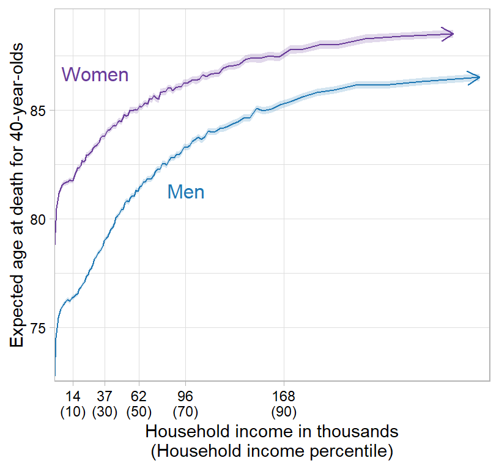

```r
#labels
xlabels <- c("14\n(10)", "37\n(30)", "62\n(50)", "96\n(70)", "168\n(90)")

ggplot(subset(chetty, hh_inc<311000), aes(x=hh_inc, y=le_raceadj, group=gnd, color=gnd, label=gnd, fill=gnd)) +
  geom_line(arrow = arrow(length=unit(0.30,"cm"), ends="last", type = "open")) +
  geom_ribbon(aes(ymin=le_raceadj-1.96*sd_le_raceadj, ymax=le_raceadj+1.96*sd_le_raceadj), alpha=0.2, lty=0) +
  geom_dl(method='smart.grid') +
  scale_color_manual(values=c("#1F78B4", "#6A3D9A")) +
  scale_fill_manual(values=c("#1F78B4", "#6A3D9A")) +
  ylab("Expected age at death for 40-year-olds") +
  xlab("Household income in thousands\n(Household income percentile)") +
  scale_y_continuous(limits=c(72.5, 89.5), expand=expansion(mult=c(0.0,0.01))) +
  scale_x_continuous(breaks=c(14000, 37000, 62000, 96000, 168000), labels=xlabels, minor_breaks=NULL, expand=expansion(mult=c(0,0.025))) +
  theme_light() +
  theme(legend.position="none", axis.text.x=element_text(color="black"), axis.text.y=element_text(color="black"))
```

# 3 EPI data on MW violations

The EPI are estimates are based on CPS data from 2013-2015. The estimates in the EPI data and the Chetty data generalize to different populations - the EPI estimates came from a sample of MW-eligible workers (88% of all workers) of any age at each family income level in the 10 largest U.S. cities, while the Chetty estimates are age-40 life expectancy among positive earners in the entire U.S. population at each HH income level.

The EPI data contains the income-pooled ratio of the prevalence of wage theft among women versus men (4.9% vs 3.5%; similar in NELP data), the gender-pooled prevalence of wage theft among each household income strata, the gender-pooled cost of wage theft among each household income strata, and the gender composition of MW eligible workers (women are 46.6% of MW eligible workers). To calculate the gender-specific prevalence of wage theft among each household income strata, we used simultaneous equations, assuming the overall women/men wage theft prevalence ratio held within income strata. It probably doesn’t precisely, since one reason women experience more wage theft than men is that they’re segregated into lower-income jobs (although the distribution of family income across genders doesn’t vary much). We assumed the cost of wage theft within each household income strata was the same across genders, which the EPI data suggests is approximately true, income aside.

```r
theft <- read.csv(here('epi_data_national.csv'), fileEncoding="UTF-8-BOM")

#estimate prevalence of theft among women and men within each income category using simultaneous equations
binded <- NULL
for(i in 1:length(theft$gnd_ratio)){
  fn <- function(x){
    eq1 <- x[1]/x[2] - theft$gnd_ratio[i]
    eq2 <- (0.466*x[1] + 0.534*x[2]) -  theft$prop_theft[i]
    return(c(eq1, eq2))
  }
  binded <- rbind(binded, nleqslv(c(1,5), fn)$x)
}

#stack gender-specific datasets
theft <- rbind(theft[,c(1:2,5:6)],
               data.frame(hh_inc_cat=theft$hh_inc_cat, prop_theft=binded[,1], yr_theft=theft$yr_theft, gnd="Women"),
               data.frame(hh_inc_cat=theft$hh_inc_cat, prop_theft=binded[,2], yr_theft=theft$yr_theft, gnd="Men"))

#print
kable(theft, col.names=c("Family income", "Percent wage theft", "Annual underpayment", "Gender"), digits=2, format.args = list(big.mark = ",", scientific = FALSE)) %>%
  kable_styling("striped") %>%
  group_rows("Overall", 1, 7) %>%
  group_rows("Women (estimated)", 8, 14) %>%
  group_rows("Men (estimated)", 15, 21) %>%
  scroll_box(width = "100%", height = "500px")
```

| Family income | Percent wage theft | Annual underpayment | Gender |
| --- | --- | --- | --- |
| **Overall** |  |  |  |
| <10000 | 0.08 | 3,500 | Overall |
| 10000-24999 | 0.07 | 3,200 | Overall |
| 25000-39999 | 0.05 | 3,200 | Overall |
| 40000-59999 | 0.04 | 3,300 | Overall |
| 60000-99999 | 0.03 | 3,200 | Overall |
| 100000-149999 | 0.03 | 3,200 | Overall |
| 150000+ | 0.03 | 3,700 | Overall |
| **Women (estimated)** |  |  |  |
| <10000 | 0.10 | 3,500 | Women |
| 10000-24999 | 0.09 | 3,200 | Women |
| 25000-39999 | 0.06 | 3,200 | Women |
| 40000-59999 | 0.05 | 3,300 | Women |
| 60000-99999 | 0.04 | 3,200 | Women |
| 100000-149999 | 0.03 | 3,200 | Women |
| 150000+ | 0.03 | 3,700 | Women |
| **Men (estimated)** |  |  |  |
| <10000 | 0.07 | 3,500 | Men |
| 10000-24999 | 0.06 | 3,200 | Men |
| 25000-39999 | 0.04 | 3,200 | Men |
| 40000-59999 | 0.03 | 3,300 | Men |
| 60000-99999 | 0.03 | 3,200 | Men |
| 100000-149999 | 0.02 | 3,200 | Men |
| 150000+ | 0.02 | 3,700 | Men |

```r
#merge the EPI and chetty data
merge(chetty, theft, c("hh_inc_cat", "gnd")) %>%
  arrange(gnd, pctile) -> chetty
```

# 4 Primary analyses

```r
#scenario function
int_func_primary <- function(prop, inc, scenario){#prop and inc are multipliers for EPI theft prevalence and cost estimates

  #seed
  set.seed(4325)

  #create sample
  chetty_tot %>%
    group_by(gnd, hh_inc_cat) %>%
    sample_frac(size=prop_theft*prop, replace=F) %>%
    mutate(hh_inc_rev=hh_inc + inc*yr_theft) %>%
    ungroup() %>%
    dplyr::select('id', 'hh_inc_rev') -> chetty_samps

  #create hypothetical income variable
  chetty_tot %>%
    left_join(chetty_samps, by='id') %>%
    mutate(hh_inc=ifelse(!is.na(hh_inc_rev), hh_inc_rev, hh_inc)) %>%
    dplyr::select(-hh_inc_rev) -> chetty_tot_int

  #simulate LE using fitted model and hypothetical income
  int1 <- cbind(chetty_tot_int, data.frame(sim_1=predict(fit, newdata = chetty_tot_int, type="response")), data.frame(type=scenario))
}

#7 spline knots since underlying data are based on over a billion observations; 7 is upper bound of what Harrell suggests
knots_7 <- as.numeric(quantile(chetty$hh_inc, c(.025, .1833, .3417, .5, .6583, .8167, .975)))

#fit models to Chetty data to interpolate across chunky income values and smooth across random dips
fit <- lm(le_raceadj ~ rcs(hh_inc, parms=knots_7)*gnd, data=chetty, w=count)

#create large expanded Chetty dataset -> we'll use this to get weighed average estimates for our various scenarios
data.frame(pctile=rep(chetty$pctile, chetty$count/1000),
           hh_inc=rep(chetty$hh_inc, chetty$count/1000),
           hh_inc_cat=rep(chetty$hh_inc_cat, chetty$count/1000),
           prop_theft=rep(chetty$prop_theft, chetty$count/1000),
           yr_theft=rep(chetty$yr_theft, chetty$count/1000),
           gnd=rep(chetty$gnd, chetty$count/1000),
           sd=rep(chetty$sd_le_raceadj, chetty$count/1000),
           ACS_pop=rep(chetty$ACS_pop, chetty$count/1000)) %>%
  mutate(id=row_number()) -> chetty_tot

#observed income-LE relationship from fitted model
obs <- cbind(chetty_tot, data.frame(sim_1=predict(fit, newdata = chetty_tot, type="response")), data.frame(type="Observed"))

#predicted LE under hypothetical scenarios
int1 <- int_func_primary(prop=1, inc=1, scenario="Scenario 1")
int2 <- int_func_primary(prop=(68/26), inc=1, scenario="Scenario 2")
int3 <- int_func_primary(prop=(68/26), inc=(1/0.58), scenario="Scenario 3")

#bind together
binded <- rbind(obs, int1, int2, int3)
```

## 4.1 Model output

```r
tidy(fit) %>%
  dplyr::select(c(term, estimate, std.error, p.value)) %>%
  mutate(estimate=ifelse(term=="gndWomen" | term=="(Intercept)", estimate, estimate*1000),
         std.error=ifelse(term=="gndWomen" | term=="(Intercept)", std.error, std.error*1000)) %>%
  kable(digits=2, caption="Income coefficients correspond to effects of changes in 1000s of dollars") %>%
  kable_styling("striped")
```

Income coefficients correspond to effects of changes in 1000s of dollars

| term | estimate | std.error | p.value |
| --- | --- | --- | --- |
| (Intercept) | 74.57 | 0.11 | 0.00 |
| rcs(hh_inc, parms = knots_7)hh_inc | 0.12 | 0.01 | 0.00 |
| rcs(hh_inc, parms = knots_7)hh_inc’ | 0.06 | 0.86 | 0.95 |
| rcs(hh_inc, parms = knots_7)hh_inc’’ | -2.04 | 2.82 | 0.47 |
| rcs(hh_inc, parms = knots_7)hh_inc’’’ | 2.03 | 3.40 | 0.55 |
| rcs(hh_inc, parms = knots_7)hh_inc’’’’ | 0.81 | 2.08 | 0.70 |
| rcs(hh_inc, parms = knots_7)hh_inc’’’’’ | -0.69 | 0.73 | 0.35 |
| gndWomen | 5.66 | 0.16 | 0.00 |
| rcs(hh_inc, parms = knots_7)hh_inc:gndWomen | 0.00 | 0.01 | 0.92 |
| rcs(hh_inc, parms = knots_7)hh_inc’:gndWomen | -3.33 | 1.19 | 0.01 |
| rcs(hh_inc, parms = knots_7)hh_inc’’:gndWomen | 8.82 | 3.90 | 0.02 |
| rcs(hh_inc, parms = knots_7)hh_inc’’’:gndWomen | -6.29 | 4.72 | 0.18 |
| rcs(hh_inc, parms = knots_7)hh_inc’’’’:gndWomen | 0.61 | 2.91 | 0.83 |
| rcs(hh_inc, parms = knots_7)hh_inc’’’’’:gndWomen | 0.01 | 1.02 | 0.99 |

```r
glance(fit) %>%
  kable(digits=3) %>%
  kable_styling("striped")
```

| r.squared | adj.r.squared | sigma | statistic | p.value | df | logLik | AIC | BIC | deviance | df.residual | nobs |
| --- | --- | --- | --- | --- | --- | --- | --- | --- | --- | --- | --- |
| 0.996 | 0.995 | 606.707 | 3200.633 | 0 | 13 | 18.571 | -7.142 | 42.333 | 68465344 | 186 | 200 |

## 4.2 Density of income distribution below median across scenarios

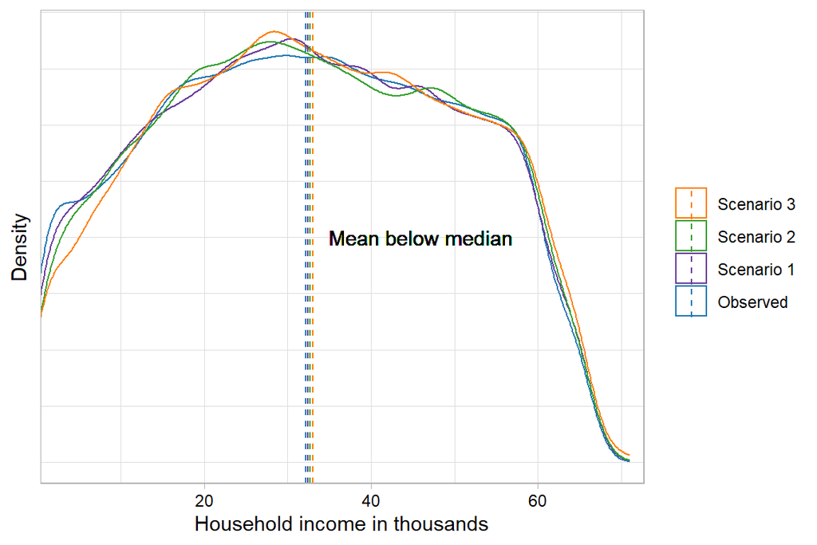

```r
#estimate mean income in each scenario in bottom half of income distribution
#don't need to sample everyone for geom_density, and not doing so speeds things up a bunch
binded %>%
  filter(pctile<=50) %>%
  group_by(type) %>%
  summarise(mean_hh_inc=mean(hh_inc)) %>%
  left_join(binded, 'type') %>%
  sample_frac(0.05, replace=F) -> binded_sub

#plot
ggplot(subset(binded_sub, pctile<=50), aes(x=hh_inc/1000)) +
  geom_density(aes(color=type, group=type)) +
  geom_text(aes(x=46, y=0.01, label="Mean below median")) +
  geom_vline(aes(xintercept=mean_hh_inc/1000, group=type, color=type), lty=2) +
  xlab("Household income in thousands") +
  ylab("Density") +
  scale_color_manual(values=c("#1F78B4", "#6A3D9A", "#33A02C", "#FF7F00")) +
  scale_x_continuous(expand=expansion(mult=c(0,0.025))) +
  theme_light() +
  theme(legend.title=element_blank(), axis.text.y=element_blank(), axis.ticks.y=element_blank(), axis.text.x=element_text(color="black"),
        strip.background=element_rect(color="darkgrey", fill=NA), strip.text=element_text(color="black")) +
  guides(color=guide_legend(reverse=T), fill=guide_legend(reverse=T))
```

## 4.3 Estimated relationship between income and expected age at death under observed scenario

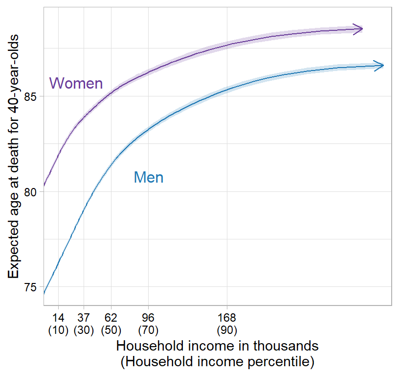

```r
#remove duplicated rows since they're identical for each income level
obs %>%
  filter(!duplicated(paste(gnd, pctile))) -> obs_sub

#labels
xlabels <- c("14\n(10)", "37\n(30)", "62\n(50)", "96\n(70)", "168\n(90)")

ggplot(subset(obs_sub, hh_inc<311000), aes(x=hh_inc, y=sim_1, group=gnd, color=gnd, label=gnd, fill=gnd)) +
  geom_line(arrow = arrow(length=unit(0.30,"cm"), ends="last", type = "open")) +
  geom_ribbon(aes(ymin=sim_1 - 1.96 * sd, ymax=sim_1 + 1.96 * sd), alpha=0.2, lty=0) +
  geom_dl(method='smart.grid') +
  scale_color_manual(values=c("#1F78B4", "#6A3D9A")) +
  scale_fill_manual(values=c("#1F78B4", "#6A3D9A")) +
  ylab("Expected age at death for 40-year-olds") +
  xlab("Household income in thousands\n(Household income percentile)") +
  scale_y_continuous(limits=c(74, 89.5), expand=expansion(mult=c(0.0,0.01))) +
  scale_x_continuous(breaks=c(14000, 37000, 62000, 96000, 168000), labels=xlabels, minor_breaks=NULL, expand=expansion(mult=c(0,0.025))) +
  theme_light() +
  theme(legend.position="none", axis.text.x=element_text(color="black"), axis.text.y=element_text(color="black"))
```

```r
ggsave('fig_1.png', height=4, width=4.25, dpi=600)
```

## 4.4 Point estimates

```r
#point estimates function
point_ests <- function(pctiled1, pctiled2, rooted, fractioned){
  binded %>%
    filter(pctile<=pctiled1) %>%
    filter(pctile>=pctiled2) %>%
    group_by(type, gnd) %>%
    summarise(meaned=mean(sim_1),
              sdd=mean(sd),
              ACS_pop=mean(ACS_pop)) %>%
    ungroup() %>%
    group_by(gnd) %>%
    mutate(meaned=meaned, #SE for Mean expected age at death is mean SE divided by sqrt of number of SE estimates [mean(SE)/sqrt(number of SE estimates, e.g., 100 in full sample; 10 w/in deciles)]
           meaned_lower=meaned-(1.96 * (sdd/sqrt(rooted))),
           meaned_upper=meaned+(1.96 * (sdd/sqrt(rooted))),
           diff=meaned-first(meaned), #SE for difference in Mean expected age at death is sqrt(2)*[mean(SE)/sqrt(number of SE estimates)] (reduced from formula for SE of diff: sqrt[(SE 1st)^2*(SE 2nd)^2])
           diff_lower=diff-(1.96 * (sqrt(2)*(sdd/sqrt(rooted)))),
           diff_upper=diff+(1.96 * (sqrt(2)*(sdd/sqrt(rooted)))),
           diff_pop=diff*ACS_pop*fractioned,
           diff_lower_pop=diff_lower*ACS_pop*fractioned,
           diff_upper_pop=diff_upper*ACS_pop*fractioned) %>%
    dplyr::select('gnd', 'type', 'meaned', 'meaned_lower', 'meaned_upper', 'diff', 'diff_lower', "diff_upper", 'diff_pop', 'diff_lower_pop', "diff_upper_pop") %>%
    arrange(desc(gnd), type)
}

#DiD function
did_ests <- function(datted=chetty){
  cbind(affected, unaffected) %>%
    filter(type...2 != "Observed") %>%
    right_join(datted[c(1,101),c("ACS_pop", "gnd")], by=c('gnd...1'='gnd')) %>%
    mutate(se_d1=(diff...6-diff_lower...7)/1.96,
           se_d10=(diff...17-diff_lower...18)/1.96,
           did=diff...6-diff...17,
           did_lower=did-1.96*sqrt(se_d1^2+se_d10^2),
           did_upper=did+1.96*sqrt(se_d1^2+se_d10^2),
           did_pop=did*ACS_pop*0.10,
           did_lower_pop=did_lower*ACS_pop*0.10,
           did_upper_pop=did_upper*ACS_pop*0.10) %>%
    select(gnd...1, type...2, did, did_lower, did_upper, did_pop, did_lower_pop, did_upper_pop) %>%
    rename(gnd=gnd...1, type=type...2)
}

#point estimates for difference in mean expected age at death across scenarios
overall <- point_ests(pctiled1=100, pctiled2=1, rooted=100, fractioned=1)

#point estimates for difference in mean expected age at death across scenarios within affected group
affected <- point_ests(pctiled1=10, pctiled2=1, rooted=10, fractioned=0.1)

#point estimates for difference in mean expected age at death across scenarios within unaffected group
unaffected <- point_ests(pctiled1=100, pctiled2=91, rooted=10, fractioned=0.1)

#DiD ests
did <- did_ests()

#print point ests
kable(rbind(overall, affected, unaffected), digits=c(2,2,2,2,2,2,2,2,0,0,0), format.args = list(big.mark = ",", scientific = FALSE),
      col.names=c("", "Scenario", "Estimate", "Lower", "Upper", "Estimate", "Lower", "Upper", "Estimate", "Lower", "Upper")) %>%
  kable_styling("striped") %>%
  add_header_above(c(" "=2, "Mean expected age at death"=3, "Diff in expected age at death"=3, "Total years extended"=3)) %>%
  group_rows("Overall", 1, 8) %>%
  group_rows("Lower HH income decile", 9, 16) %>%
  group_rows("Upper HH income decile", 17, 24)
```

|  | Scenario | Mean expected age at death Estimate | Mean expected age at death Lower | Mean expected age at death Upper | Diff in expected age at death Estimate | Diff in expected age at death Lower | Diff in expected age at death Upper | Total years extended Estimate | Total years extended Lower | Total years extended Upper |
| --- | --- | --- | --- | --- | --- | --- | --- | --- | --- | --- |
| **Overall** |  |  |  |  |  |  |  |  |  |  |
| Women | Observed | 84.93 | 84.91 | 84.95 | 0.00 | -0.02 | 0.02 | 0 | -696,558 | 696,558 |
| Women | Scenario 1 | 84.94 | 84.93 | 84.96 | 0.01 | -0.01 | 0.03 | 333,163 | -363,395 | 1,029,721 |
| Women | Scenario 2 | 84.96 | 84.94 | 84.97 | 0.03 | 0.01 | 0.05 | 871,072 | 174,513 | 1,567,630 |
| Women | Scenario 3 | 84.98 | 84.96 | 84.99 | 0.05 | 0.02 | 0.07 | 1,471,717 | 775,159 | 2,168,275 |
| Men | Observed | 81.28 | 81.27 | 81.30 | 0.00 | -0.02 | 0.02 | 0 | -593,409 | 593,409 |
| Men | Scenario 1 | 81.29 | 81.28 | 81.30 | 0.01 | -0.01 | 0.03 | 294,502 | -298,906 | 887,911 |
| Men | Scenario 2 | 81.31 | 81.29 | 81.32 | 0.02 | 0.01 | 0.04 | 770,457 | 177,048 | 1,363,866 |
| Men | Scenario 3 | 81.32 | 81.31 | 81.34 | 0.04 | 0.02 | 0.06 | 1,317,428 | 724,019 | 1,910,837 |
| **Lower HH income decile** |  |  |  |  |  |  |  |  |  |  |
| Women | Observed | 81.16 | 81.12 | 81.20 | 0.00 | -0.06 | 0.06 | 0 | -182,668 | 182,668 |
| Women | Scenario 1 | 81.20 | 81.16 | 81.24 | 0.04 | -0.02 | 0.10 | 119,848 | -62,819 | 302,516 |
| Women | Scenario 2 | 81.26 | 81.22 | 81.30 | 0.10 | 0.04 | 0.16 | 309,916 | 127,248 | 492,583 |
| Women | Scenario 3 | 81.33 | 81.29 | 81.37 | 0.17 | 0.11 | 0.22 | 528,685 | 346,018 | 711,353 |
| Men | Observed | 75.48 | 75.44 | 75.51 | 0.00 | -0.05 | 0.05 | 0 | -150,872 | 150,872 |
| Men | Scenario 1 | 75.50 | 75.47 | 75.54 | 0.03 | -0.02 | 0.08 | 84,130 | -66,742 | 235,003 |
| Men | Scenario 2 | 75.55 | 75.51 | 75.58 | 0.07 | 0.02 | 0.12 | 220,652 | 69,780 | 371,524 |
| Men | Scenario 3 | 75.60 | 75.57 | 75.63 | 0.12 | 0.07 | 0.17 | 380,502 | 229,630 | 531,374 |
| **Upper HH income decile** |  |  |  |  |  |  |  |  |  |  |
| Women | Observed | 88.29 | 88.23 | 88.35 | 0.00 | -0.09 | 0.09 | 0 | -269,771 | 269,771 |
| Women | Scenario 1 | 88.29 | 88.23 | 88.35 | 0.00 | -0.08 | 0.09 | 1,995 | -267,775 | 271,766 |
| Women | Scenario 2 | 88.29 | 88.23 | 88.35 | 0.00 | -0.08 | 0.09 | 5,088 | -264,683 | 274,859 |
| Women | Scenario 3 | 88.29 | 88.23 | 88.35 | 0.00 | -0.08 | 0.09 | 8,622 | -261,149 | 278,392 |
| Men | Observed | 86.35 | 86.30 | 86.40 | 0.00 | -0.07 | 0.07 | 0 | -228,262 | 228,262 |
| Men | Scenario 1 | 86.35 | 86.30 | 86.40 | 0.00 | -0.07 | 0.07 | 1,641 | -226,620 | 229,903 |
| Men | Scenario 2 | 86.35 | 86.30 | 86.40 | 0.00 | -0.07 | 0.08 | 4,314 | -223,948 | 232,576 |
| Men | Scenario 3 | 86.35 | 86.30 | 86.41 | 0.00 | -0.07 | 0.08 | 7,304 | -220,957 | 235,566 |

```r
#print did
kable(did, digits=c(2,2,2,2,2,0,0,0), format.args = list(big.mark = ",", scientific = FALSE),
      col.names=c("", "Scenario", "Estimate", "Lower", "Upper", "Estimate", "Lower", "Upper")) %>%
  kable_styling("striped") %>%
  add_header_above(c(" "=2, "DiD in expected age at death"=3, "DiD in years extended"=3))
```

|  | Scenario | DiD in expected age at death Estimate | DiD in expected age at death Lower | DiD in expected age at death Upper | DiD in years extended Estimate | DiD in years extended Lower | DiD in years extended Upper |
| --- | --- | --- | --- | --- | --- | --- | --- |
| Women | Scenario 1 | 0.04 | -0.07 | 0.14 | 117,853 | -207,944 | 443,650 |
| Women | Scenario 2 | 0.10 | -0.01 | 0.20 | 304,828 | -20,969 | 630,625 |
| Women | Scenario 3 | 0.16 | 0.06 | 0.27 | 520,064 | 194,267 | 845,861 |
| Men | Scenario 1 | 0.03 | -0.06 | 0.12 | 82,489 | -191,127 | 356,105 |
| Men | Scenario 2 | 0.07 | -0.02 | 0.16 | 216,338 | -57,278 | 489,955 |
| Men | Scenario 3 | 0.12 | 0.03 | 0.21 | 373,198 | 99,581 | 646,814 |

## 4.5 Plots

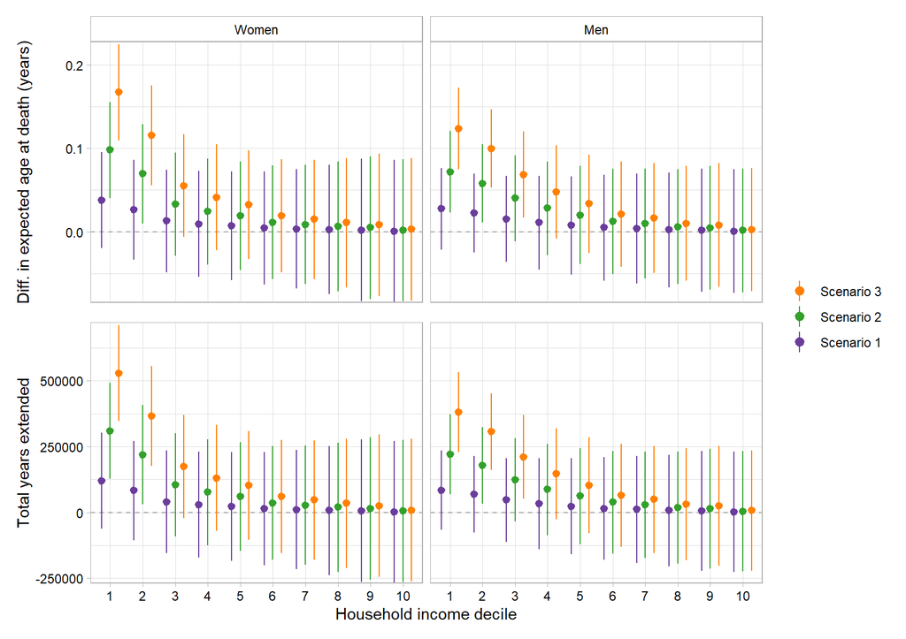

```r
#point estimates by decile function
point_ests_plots <- function(){
  binded %>%
    mutate(decile=cut_interval(pctile, 10),
           gnd=factor(gnd, levels=c("Women", "Men"))) %>%
    group_by(gnd, decile, type) %>%
    summarise(meaned=mean(sim_1),
              sdd=mean(sd),
              ACS_pop=mean(ACS_pop)) %>%
    arrange(gnd, decile, type) %>%
    ungroup() %>%
    group_by(gnd, decile) %>%
    mutate(diff=meaned-first(meaned), #SE for difference in Mean expected age at death is sqrt(2)*[mean(SE)/sqrt(number of SE estimates)] (reduced from formula for SE of diff: sqrt[(SE 1st)^2*(SE 2nd)^2])
           diff_lower=diff-(1.96 * (sqrt(2)*(sdd/sqrt(10)))),
           diff_upper=diff+(1.96 * (sqrt(2)*(sdd/sqrt(10)))),
           diff_pop=diff*ACS_pop*0.1,
           diff_lower_pop=diff_lower*ACS_pop*0.1,
           diff_upper_pop=diff_upper*ACS_pop*0.1) %>%
    filter(type!="Observed") %>%
    dplyr::select('gnd', 'type', 'decile', 'diff', 'diff_lower', "diff_upper", 'diff_pop', 'diff_lower_pop', "diff_upper_pop", "ACS_pop")
}

#plot point estimates by decile function
plot_deciles_est <- function(vals=c("#6A3D9A", "#33A02C", "#FF7F00"), fattened=3, widthed=0.8){
  ggplot(deciles, aes(x=decile, y=diff, group=type, color=type, fill=type)) +
    facet_wrap(~gnd) +
    geom_hline(yintercept=0, lty=2, color="darkgrey") +
    geom_pointrange(aes(y=diff, ymin=diff_lower, ymax=diff_upper), size=0.5, fatten=fattened, position=position_dodge(width=widthed)) +
    scale_color_manual(values=vals) +
    scale_fill_manual(values=vals) +
    ylab("Diff. in expected age at death (years)") +
    scale_y_continuous(expand=expansion(mult=c(0.0, 0.01)),  limits=c(min(deciles$diff_lower), max(deciles$diff_upper))) +
    theme_light() +
    theme(strip.background=element_rect(color="darkgrey", fill=NA), strip.text=element_text(color="black"),
          axis.title.x=element_blank(), axis.text.x=element_blank(), axis.ticks.x=element_blank(), axis.text.y=element_text(color="black"))
}

#plot total years extended by decile function
plot_deciles_tot <- function(vals=c("#6A3D9A", "#33A02C", "#FF7F00"), fattened=3, widthed=0.8){
  ggplot(deciles, aes(x=decile, y=diff_pop, group=type, color=type, fill=type)) +
    facet_wrap(~gnd) +
    geom_hline(yintercept=0, lty=2, color="darkgrey") +
    geom_pointrange(aes(y=diff_pop, ymin=diff_lower_pop, ymax=diff_upper_pop), size=0.5, fatten=fattened, position=position_dodge(width=widthed)) +
    scale_color_manual(values=vals) +
    scale_fill_manual(values=vals) +
    ylab("Total years extended") +
    xlab("Household income decile") +
    scale_y_continuous(expand=expansion(mult=c(0.0, 0.01)),  limits=c(min(deciles$diff_lower_pop), max(deciles$diff_upper_pop))) +
    scale_x_discrete(labels=c('1', "2", "3", "4", "5", "6", "7", "8", "9", "10")) +
    theme_light() +
    theme(strip.background=element_blank(), strip.text=element_blank(), axis.text.x=element_text(color="black"), axis.text.y=element_text(color="black"))
}

#decile point estimates
deciles <- point_ests_plots()

#plot
p1 <- plot_deciles_est()
p2 <- plot_deciles_tot()

p1 + p2 + plot_layout(guides = "collect", nrow=2) & theme(legend.position = "right", legend.title=element_blank()) & guides(color=guide_legend(reverse=T), fill=guide_legend(reverse=T))
```

```r
ggsave('fig_2.png', height=6, width=8.5, dpi=600)
```

# 5 Supplementary analyses

## 5.1 Using loess to model income rather than a spline

```r
#scenario function
int_func_loess <- function(prop, inc, scenario){#prop and inc are multipliers for EPI theft prevalence and cost estimates

  #seed
  set.seed(4325)

  #create sample
  chetty_tot %>%
    group_by(gnd, hh_inc_cat) %>%
    sample_frac(size=prop_theft*prop, replace=F) %>%
    mutate(hh_inc_rev=hh_inc + inc*yr_theft) %>%
    ungroup() %>%
    dplyr::select('id', 'hh_inc_rev') -> chetty_samps

  #create hypothetical income variable
  chetty_tot %>%
    left_join(chetty_samps, by='id') %>%
    mutate(hh_inc=ifelse(!is.na(hh_inc_rev), hh_inc_rev, hh_inc)) %>%
    dplyr::select(-hh_inc_rev) -> chetty_tot_int

  #simulate LE using fitted model and hypothetical income
  int1 <- rbind(cbind(subset(chetty_tot_int, gnd=="Women"), data.frame(sim_1=predict(fit_women, newdata = subset(chetty_tot_int, gnd=="Women"), type="response")), data.frame(type=scenario)),
                cbind(subset(chetty_tot_int, gnd=="Men"), data.frame(sim_1=predict(fit_men, newdata = subset(chetty_tot_int, gnd=="Men"), type="response")), data.frame(type=scenario)))
}

#fit models to Chetty data to interpolate across chunky income values; might as well use very small span, given purpose of this sensitivity analysis
fit_women <- loess(le_raceadj ~ hh_inc, span=0.05, control=loess.control(surface='direct'), data=subset(chetty, gnd=="Women"), w=count)
fit_men <- loess(le_raceadj ~ hh_inc, span=0.05, control=loess.control(surface='direct'), data=subset(chetty, gnd=="Men"), w=count)

#create large expanded Chetty dataset -> we'll use this to get weighed average estimates for our various scenarios
data.frame(pctile=rep(chetty$pctile, chetty$count/1000),
           hh_inc=rep(chetty$hh_inc, chetty$count/1000),
           hh_inc_cat=rep(chetty$hh_inc_cat, chetty$count/1000),
           prop_theft=rep(chetty$prop_theft, chetty$count/1000),
           yr_theft=rep(chetty$yr_theft, chetty$count/1000),
           gnd=rep(chetty$gnd, chetty$count/1000),
           sd=rep(chetty$sd_le_raceadj, chetty$count/1000),
           ACS_pop=rep(chetty$ACS_pop, chetty$count/1000)) %>%
  mutate(id=row_number()) -> chetty_tot

#observed relationship between income and expected age at death from fitted model
obs <- rbind(cbind(subset(chetty_tot, gnd=="Women"), data.frame(sim_1=predict(fit_women, newdata = subset(chetty_tot, gnd=="Women"), type="response")), data.frame(type="Observed")),
             cbind(subset(chetty_tot, gnd=="Men"), data.frame(sim_1=predict(fit_men, newdata = subset(chetty_tot, gnd=="Men"), type="response")), data.frame(type="Observed")))

#predicted expected age at death under hypothetical scenarios
int1 <- int_func_loess(prop=1, inc=1, scenario="Scenario 1")
int2 <- int_func_loess(prop=(68/26), inc=1, scenario="Scenario 2")
int3 <- int_func_loess(prop=(68/26), inc=(1/0.58), scenario="Scenario 3")

#bind together
binded <- rbind(obs, int1, int2, int3)
```

### 5.1.1 Estimated relationship between income and expected age at death under observed scenario

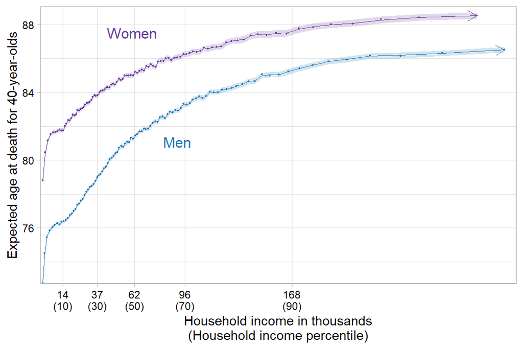

```r
#remove duplicated rows since they're identical for each income level
obs %>%
  filter(!duplicated(paste(gnd, pctile))) %>%
  right_join(chetty[,c("hh_inc", "le_raceadj", "gnd")], by=c("gnd", "hh_inc")) -> obs_sub

#labels
xlabels <- c("14\n(10)", "37\n(30)", "62\n(50)", "96\n(70)", "168\n(90)")

ggplot(subset(obs_sub, hh_inc<311000), aes(x=hh_inc, y=sim_1, group=gnd, color=gnd, label=gnd, fill=gnd)) +
  geom_point(aes(y=le_raceadj), size=0.35) +
  geom_line(size=0.2, arrow = arrow(length=unit(0.30,"cm"), ends="last", type = "open")) +
  geom_ribbon(aes(ymin=sim_1 - 1.96 * sd, ymax=sim_1 + 1.96 * sd), alpha=0.2, lty=0) +
  geom_dl(method='smart.grid') +
  scale_color_manual(values=c("#1F78B4", "#6A3D9A")) +
  scale_fill_manual(values=c("#1F78B4", "#6A3D9A")) +
  ylab("Expected age at death for 40-year-olds") +
  xlab("Household income in thousands\n(Household income percentile)") +
  scale_y_continuous(limits=c(72.7, 88.9), expand=expansion(mult=c(0.0,0.01))) +
  scale_x_continuous(breaks=c(14000, 37000, 62000, 96000, 168000), labels=xlabels, minor_breaks=NULL, expand=expansion(mult=c(0.005,0.025))) +
  theme_light() +
  theme(legend.position="none", axis.text.x=element_text(color="black"), axis.text.y=element_text(color="black"))
```

```r
ggsave('appendix_1a.png', height=4, width=6, dpi=600)
```

### 5.1.2 Point estimates

```r
#point estimates for difference in mean expected age at death across scenarios
overall <- point_ests(pctiled1=100, pctiled2=1, rooted=100, fractioned=1)

#point estimates for difference in mean expected age at death across scenarios within affected group
affected <- point_ests(pctiled1=10, pctiled2=1, rooted=10, fractioned=0.1)

#point estimates for difference in mean expected age at death across scenarios within unaffected group
unaffected <- point_ests(pctiled1=100, pctiled2=91, rooted=10, fractioned=0.1)

#DiD ests
did <- did_ests()

#print point ests
kable(rbind(overall, affected, unaffected), digits=c(2,2,2,2,2,2,2,2,0,0,0), format.args = list(big.mark = ",", scientific = FALSE),
      col.names=c("", "Scenario", "Estimate", "Lower", "Upper", "Estimate", "Lower", "Upper", "Estimate", "Lower", "Upper")) %>%
  kable_styling("striped") %>%
  add_header_above(c(" "=2, "Mean expected age at death"=3, "Diff in expected age at death"=3, "Total years extended"=3)) %>%
  group_rows("Overall", 1, 8) %>%
  group_rows("Lower HH income decile", 9, 16) %>%
  group_rows("Upper HH income decile", 17, 24)
```

|  | Scenario | Mean expected age at death Estimate | Mean expected age at death Lower | Mean expected age at death Upper | Diff in expected age at death Estimate | Diff in expected age at death Lower | Diff in expected age at death Upper | Total years extended Estimate | Total years extended Lower | Total years extended Upper |
| --- | --- | --- | --- | --- | --- | --- | --- | --- | --- | --- |
| **Overall** |  |  |  |  |  |  |  |  |  |  |
| Women | Observed | 84.93 | 84.91 | 84.95 | 0.00 | -0.02 | 0.02 | 0 | -696,558 | 696,558 |
| Women | Scenario 1 | 84.94 | 84.93 | 84.96 | 0.01 | -0.01 | 0.03 | 374,883 | -321,675 | 1,071,442 |
| Women | Scenario 2 | 84.96 | 84.95 | 84.98 | 0.03 | 0.01 | 0.05 | 987,199 | 290,641 | 1,683,757 |
| Women | Scenario 3 | 84.98 | 84.96 | 84.99 | 0.05 | 0.03 | 0.07 | 1,523,183 | 826,625 | 2,219,741 |
| Men | Observed | 81.28 | 81.27 | 81.30 | 0.00 | -0.02 | 0.02 | 0 | -593,409 | 593,409 |
| Men | Scenario 1 | 81.29 | 81.28 | 81.31 | 0.01 | -0.01 | 0.03 | 342,150 | -251,259 | 935,558 |
| Men | Scenario 2 | 81.31 | 81.30 | 81.32 | 0.03 | 0.01 | 0.05 | 893,032 | 299,623 | 1,486,441 |
| Men | Scenario 3 | 81.33 | 81.31 | 81.34 | 0.05 | 0.03 | 0.06 | 1,393,546 | 800,137 | 1,986,955 |
| **Lower HH income decile** |  |  |  |  |  |  |  |  |  |  |
| Women | Observed | 81.22 | 81.18 | 81.26 | 0.00 | -0.06 | 0.06 | 0 | -182,668 | 182,668 |
| Women | Scenario 1 | 81.27 | 81.23 | 81.31 | 0.05 | -0.01 | 0.11 | 164,665 | -18,002 | 347,333 |
| Women | Scenario 2 | 81.35 | 81.31 | 81.39 | 0.14 | 0.08 | 0.20 | 436,051 | 253,383 | 618,718 |
| Women | Scenario 3 | 81.40 | 81.36 | 81.44 | 0.18 | 0.13 | 0.24 | 585,885 | 403,217 | 768,553 |
| Men | Observed | 75.59 | 75.56 | 75.63 | 0.00 | -0.05 | 0.05 | 0 | -150,872 | 150,872 |
| Men | Scenario 1 | 75.64 | 75.60 | 75.67 | 0.04 | -0.01 | 0.09 | 129,719 | -21,153 | 280,591 |
| Men | Scenario 2 | 75.71 | 75.67 | 75.74 | 0.11 | 0.06 | 0.16 | 341,127 | 190,255 | 492,000 |
| Men | Scenario 3 | 75.74 | 75.70 | 75.77 | 0.14 | 0.09 | 0.19 | 441,827 | 290,955 | 592,699 |
| **Upper HH income decile** |  |  |  |  |  |  |  |  |  |  |
| Women | Observed | 88.28 | 88.22 | 88.34 | 0.00 | -0.09 | 0.09 | 0 | -269,771 | 269,771 |
| Women | Scenario 1 | 88.29 | 88.22 | 88.35 | 0.00 | -0.08 | 0.09 | 2,092 | -267,678 | 271,863 |
| Women | Scenario 2 | 88.29 | 88.23 | 88.35 | 0.00 | -0.08 | 0.09 | 5,454 | -264,316 | 275,225 |
| Women | Scenario 3 | 88.29 | 88.23 | 88.35 | 0.00 | -0.08 | 0.09 | 8,710 | -261,061 | 278,480 |
| Men | Observed | 86.36 | 86.30 | 86.41 | 0.00 | -0.07 | 0.07 | 0 | -228,262 | 228,262 |
| Men | Scenario 1 | 86.36 | 86.30 | 86.41 | 0.00 | -0.07 | 0.07 | 1,601 | -226,661 | 229,862 |
| Men | Scenario 2 | 86.36 | 86.31 | 86.41 | 0.00 | -0.07 | 0.08 | 4,249 | -224,013 | 232,511 |
| Men | Scenario 3 | 86.36 | 86.31 | 86.41 | 0.00 | -0.07 | 0.08 | 6,619 | -221,643 | 234,880 |

```r
#print did
kable(did, digits=c(2,2,2,2,2,0,0,0), format.args = list(big.mark = ",", scientific = FALSE),
      col.names=c("", "Scenario", "Estimate", "Lower", "Upper", "Estimate", "Lower", "Upper")) %>%
  kable_styling("striped") %>%
  add_header_above(c(" "=2, "DiD in expected age at death"=3, "DiD in years extended"=3))
```

|  | Scenario | DiD in expected age at death Estimate | DiD in expected age at death Lower | DiD in expected age at death Upper | DiD in years extended Estimate | DiD in years extended Lower | DiD in years extended Upper |
| --- | --- | --- | --- | --- | --- | --- | --- |
| Women | Scenario 1 | 0.05 | -0.05 | 0.15 | 162,573 | -163,224 | 488,370 |
| Women | Scenario 2 | 0.14 | 0.03 | 0.24 | 430,596 | 104,799 | 756,393 |
| Women | Scenario 3 | 0.18 | 0.08 | 0.28 | 577,175 | 251,378 | 902,972 |
| Men | Scenario 1 | 0.04 | -0.05 | 0.13 | 128,118 | -145,498 | 401,735 |
| Men | Scenario 2 | 0.11 | 0.02 | 0.20 | 336,878 | 63,262 | 610,494 |
| Men | Scenario 3 | 0.14 | 0.05 | 0.23 | 435,208 | 161,592 | 708,825 |

### 5.1.3 Plots

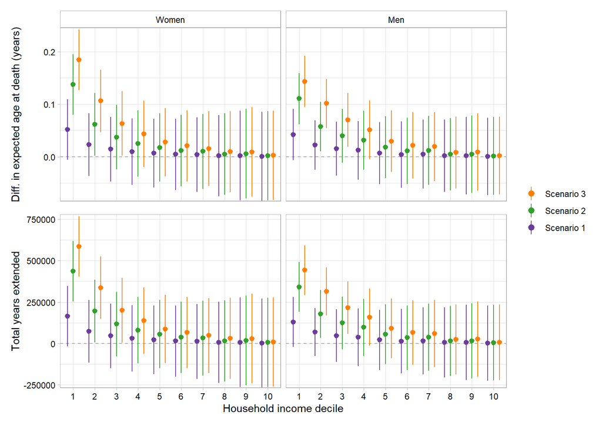

```r
#decile point estimates
deciles <- point_ests_plots()

#plot
p1 <- plot_deciles_est()
p2 <- plot_deciles_tot()

p1 + p2 + plot_layout(guides = "collect", nrow=2) & theme(legend.position = "right", legend.title=element_blank()) & guides(color=guide_legend(reverse=T), fill=guide_legend(reverse=T))
```

```r
ggsave('appendix_1d.png', height=6, width=8.5, dpi=600)
```

## 5.2 Using 2014 data alone

```r
#######create 2014 dataset
####
#
read.csv(here('health_ineq_online_table_2.csv')) %>%
  filter(year==2014) %>%
  mutate(gnd=factor(ifelse(gnd=="M", "Men", "Women"), levels=c("Women", "Men")),
         hh_inc=hh_inc*(352.6/337.3), #adjust Chetty estimates to 2016 dollars from 2012 dollars using CPI-U-RS (Chetty estimates in 2012 dollars, EPI estimates in 2016??)
         hh_inc_cat=ifelse(hh_inc<10000, "<10000",
                           ifelse(hh_inc>=10000 & hh_inc<25000, "10000-24999",
                                  ifelse(hh_inc>=25000 & hh_inc<40000, "25000-39999",
                                         ifelse(hh_inc>=40000 & hh_inc<60000, "40000-59999",
                                                ifelse(hh_inc>=60000 & hh_inc<99999, "60000-99999",
                                                       ifelse(hh_inc>=100000 & hh_inc<150000, "100000-149999",
                                                              ifelse(hh_inc>=150000, "150000+", "del")))))))) -> chetty_2014

#merge in ACS data on population counts in 2014; restrict to those with non-zero incomes, age 40, and not living in group quarters (per IPUMS recommendation)
fread(here("ACS_IPUMS_2001_2014.csv")) %>%
  filter(FTOTINC>0 & AGE==40 & YEAR==2014 & (GQ==1 | GQ==2)) %>% #family income yields similar estimates to household income, but I assume "family income" is a bit closer to Chetty's definition since joint tax filers are likely to be related
  mutate(gnd=ifelse(SEX==1, "Men", "Women")) %>%
  group_by(gnd) %>%
  summarise(ACS_pop=sum(PERWT)) %>%
  right_join(chetty_2014, by="gnd") -> chetty_2014 #~2.05-2.1 million of each gender

#merge the EPI and chetty data
merge(chetty_2014, theft, c("hh_inc_cat", "gnd")) %>%
  arrange(gnd, pctile) -> chetty_2014
```

```r
#scenario function
int_func_2014 <- function(prop, inc, scenario){#prop and inc are multipliers for EPI theft prevalence and cost estimates

  #seed
  set.seed(4325)

  #create sample
  chetty_tot_2014 %>%
    group_by(gnd, hh_inc_cat) %>%
    sample_frac(size=prop_theft*prop, replace=F) %>%
    mutate(hh_inc_rev=hh_inc + inc*yr_theft) %>%
    ungroup() %>%
    dplyr::select('id', 'hh_inc_rev') -> chetty_samps_2014

  #create hypothetical income variable
  chetty_tot_2014 %>%
    left_join(chetty_samps_2014, by='id') %>%
    mutate(hh_inc=ifelse(!is.na(hh_inc_rev), hh_inc_rev, hh_inc)) %>%
    dplyr::select(-hh_inc_rev) -> chetty_tot_int_2014

  #simulate LE using fitted model and hypothetical income
  int1 <- cbind(chetty_tot_int_2014, data.frame(sim_1=predict(fit, newdata = chetty_tot_int_2014, type="response")), data.frame(type=scenario))
}

#7 spline knots since underlying data are based on over a billion observations
knots_7 <- as.numeric(quantile(chetty_2014$hh_inc, c(.025, .1833, .3417, .5, .6583, .8167, .975)))

#fit models to Chetty data to interpolate across chunky income values and smooth across random dips
fit <- lm(le_raceadj ~ rcs(hh_inc, parms=knots_7)*gnd, data=chetty_2014, w=count)

#create large expanded Chetty dataset -> we'll use this to get weighed average estimates for our various scenarios
data.frame(pctile=rep(chetty_2014$pctile, chetty_2014$count/100),
           hh_inc=rep(chetty_2014$hh_inc, chetty_2014$count/100),
           hh_inc_cat=rep(chetty_2014$hh_inc_cat, chetty_2014$count/100),
           prop_theft=rep(chetty_2014$prop_theft, chetty_2014$count/100),
           yr_theft=rep(chetty_2014$yr_theft, chetty_2014$count/100),
           gnd=rep(chetty_2014$gnd, chetty_2014$count/100),
           sd=rep(chetty_2014$sd_le_raceadj, chetty_2014$count/100),
           ACS_pop=rep(chetty_2014$ACS_pop, chetty_2014$count/100)) %>%
  mutate(id=row_number()) -> chetty_tot_2014

#observed relationship between income and expected age at death from fitted model
obs <- cbind(chetty_tot_2014, data.frame(sim_1=predict(fit, newdata = chetty_tot_2014, type="response")), data.frame(type="Observed"))

#predicted expected age at death under hypothetical scenarios
int1 <- int_func_2014(prop=1, inc=1, scenario="Scenario 1")
int2 <- int_func_2014(prop=(68/26), inc=1, scenario="Scenario 2")
int3 <- int_func_2014(prop=(68/26), inc=(1/0.58), scenario="Scenario 3")

#bind together
binded <- rbind(obs, int1, int2, int3)
```

### 5.2.1 Model output

```r
tidy(fit) %>%
  dplyr::select(c(term, estimate, std.error, p.value)) %>%
  mutate(estimate=ifelse(term=="gndWomen" | term=="(Intercept)", estimate, estimate*1000),
         std.error=ifelse(term=="gndWomen" | term=="(Intercept)", std.error, std.error*1000)) %>%
  kable(digits=2, caption="Income coefficients correspond to effects of changes in 1000s of dollars") %>%
  kable_styling("striped")
```

Income coefficients correspond to effects of changes in 1000s of dollars

| term | estimate | std.error | p.value |
| --- | --- | --- | --- |
| (Intercept) | 74.91 | 0.26 | 0.00 |
| rcs(hh_inc, parms = knots_7)hh_inc | 0.16 | 0.02 | 0.00 |
| rcs(hh_inc, parms = knots_7)hh_inc’ | -2.22 | 2.04 | 0.28 |
| rcs(hh_inc, parms = knots_7)hh_inc’’ | 5.74 | 6.39 | 0.37 |
| rcs(hh_inc, parms = knots_7)hh_inc’’’ | -6.93 | 7.13 | 0.33 |
| rcs(hh_inc, parms = knots_7)hh_inc’’’’ | 4.76 | 3.93 | 0.23 |
| rcs(hh_inc, parms = knots_7)hh_inc’’’’’ | -1.06 | 1.31 | 0.42 |
| gndWomen | 5.84 | 0.36 | 0.00 |
| rcs(hh_inc, parms = knots_7)hh_inc:gndWomen | 0.03 | 0.03 | 0.23 |
| rcs(hh_inc, parms = knots_7)hh_inc’:gndWomen | -5.25 | 2.82 | 0.06 |
| rcs(hh_inc, parms = knots_7)hh_inc’’:gndWomen | 11.69 | 8.83 | 0.19 |
| rcs(hh_inc, parms = knots_7)hh_inc’’’:gndWomen | -6.15 | 9.88 | 0.53 |
| rcs(hh_inc, parms = knots_7)hh_inc’’’’:gndWomen | -0.20 | 5.50 | 0.97 |
| rcs(hh_inc, parms = knots_7)hh_inc’’’’’:gndWomen | -0.48 | 1.85 | 0.80 |

```r
glance(fit) %>%
  kable(digits=3) %>%
  kable_styling("striped")
```

| r.squared | adj.r.squared | sigma | statistic | p.value | df | logLik | AIC | BIC | deviance | df.residual | nobs |
| --- | --- | --- | --- | --- | --- | --- | --- | --- | --- | --- | --- |
| 0.982 | 0.98 | 343.3 | 765.229 | 0 | 13 | -146.956 | 323.912 | 373.387 | 21921002 | 186 | 200 |

### 5.2.2 Relationship between income and expected age at death by year

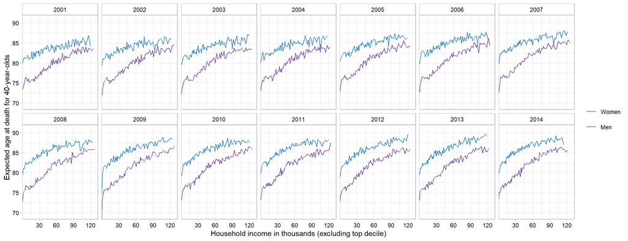

```r
read.csv(here('health_ineq_online_table_2.csv')) %>%
  mutate(hh_inc=hh_inc*(352.6/337.3), #adjust Chetty estimates to 2016 dollars from 2012 dollars using CPI-U-RS (Chetty estimates in 2012 dollars, EPI estimates in 2016??)
         gnd=factor(ifelse(gnd=="M", "Men", "Women"), levels=c("Women", "Men"))) -> chetty_annual

ggplot(subset(chetty_annual, pctile<=80), aes(x=hh_inc, y=le_raceadj, group=gnd, color=gnd, label=gnd, fill=gnd)) +
  facet_wrap(~year, nrow=2) +
  geom_line() +
  scale_color_manual(values=c("#1F78B4", "#6A3D9A")) +
  scale_fill_manual(values=c("#1F78B4", "#6A3D9A")) +
  ylab("Expected age at death for 40-year-olds") +
  xlab("Household income in thousands (excluding top decile)") +
  scale_y_continuous(expand=expansion(mult=c(0.0,0.1))) +
  scale_x_continuous(breaks=c(0, 30000, 60000, 90000, 120000), labels=c("0", "30", "60", "90", "120"), expand=expansion(mult=c(0.0,0.04))) +
  theme_light() +
  guides(color=guide_legend(nrow=2,byrow=TRUE)) +
  theme(strip.background=element_rect(color="darkgrey", fill=NA), strip.text=element_text(color="black"), legend.title=element_blank(),
        axis.text.x=element_text(color="black"), axis.text.y=element_text(color="black"))
```

```r
ggsave("appendix_2.png", height=5, width=13, dpi=600)
```

### 5.2.3 Estimated relationship between income and expected age at death for 40-year-olds under observed scenario in 2014

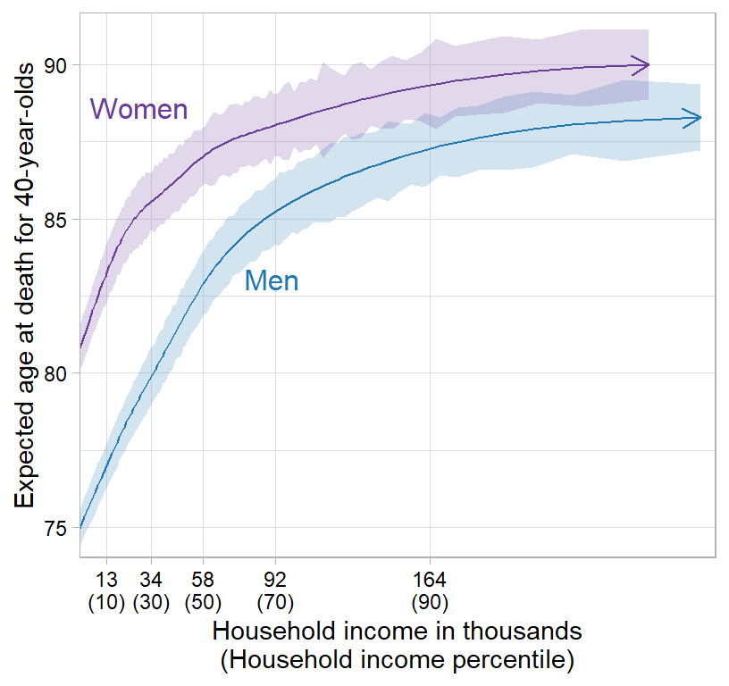

```r
#remove duplicated rows since they're identical for each income level
obs %>%
  filter(!duplicated(paste(gnd, pctile))) -> obs_sub

#labels
xlabels <- c("13\n(10)", "34\n(30)", "58\n(50)", "92\n(70)", "164\n(90)")

ggplot(subset(obs_sub, hh_inc<311000), aes(x=hh_inc, y=sim_1, group=gnd, color=gnd, label=gnd, fill=gnd)) +
  geom_line(arrow = arrow(length=unit(0.30,"cm"), ends="last", type = "open")) +
  geom_ribbon(aes(ymin=sim_1 - 1.96 * sd, ymax=sim_1 + 1.96 * sd), alpha=0.2, lty=0) +
  geom_dl(method='smart.grid') +
  scale_color_manual(values=c("#1F78B4", "#6A3D9A")) +
  scale_fill_manual(values=c("#1F78B4", "#6A3D9A")) +
  ylab("Expected age at death for 40-year-olds") +
  xlab("Household income in thousands\n(Household income percentile)") +
  scale_y_continuous(limits=c(74, 91.5), expand=expansion(mult=c(0.0,0.01))) +
  scale_x_continuous(breaks=c(13000, 34000, 58000, 92000, 164000), labels=xlabels, minor_breaks=NULL, expand=expansion(mult=c(0,0.025))) +
  theme_light() +
  theme(legend.position="none", axis.text.x=element_text(color="black"), axis.text.y=element_text(color="black"))
```

```r
ggsave('appendix_3a.png', height=4, width=4.25, dpi=600)
```

### 5.2.4 Point estimates

```r
#point estimates for difference in mean expected age at death across scenarios
overall <- point_ests(pctiled1=100, pctiled2=1, rooted=100, fractioned=1)

#point estimates for difference in mean expected age at death across scenarios within affected group
affected <- point_ests(pctiled1=10, pctiled2=1, rooted=10, fractioned=0.1)

#point estimates for difference in mean expected age at death across scenarios within unaffected group
unaffected <- point_ests(pctiled1=100, pctiled2=91, rooted=10, fractioned=0.1)

#DiD ests
did <- did_ests(datted=chetty_2014)

#print point ests
kable(rbind(overall, affected, unaffected), digits=c(2,2,2,2,2,2,2,2,0,0,0), format.args = list(big.mark = ",", scientific = FALSE),
      col.names=c("", "Scenario", "Estimate", "Lower", "Upper", "Estimate", "Lower", "Upper", "Estimate", "Lower", "Upper")) %>%
  kable_styling("striped") %>%
  add_header_above(c(" "=2, "Mean expected age at death"=3, "Diff in expected age at death"=3, "Total years extended"=3)) %>%
  group_rows("Overall", 1, 8) %>%
  group_rows("Lower HH income decile", 9, 16) %>%
  group_rows("Upper HH income decile", 17, 24)
```

|  | Scenario | Mean expected age at death Estimate | Mean expected age at death Lower | Mean expected age at death Upper | Diff in expected age at death Estimate | Diff in expected age at death Lower | Diff in expected age at death Upper | Total years extended Estimate | Total years extended Lower | Total years extended Upper |
| --- | --- | --- | --- | --- | --- | --- | --- | --- | --- | --- |
| **Overall** |  |  |  |  |  |  |  |  |  |  |
| Women | Observed | 86.55 | 86.45 | 86.66 | 0.00 | -0.15 | 0.15 | 0 | -306,335 | 306,335 |
| Women | Scenario 1 | 86.57 | 86.46 | 86.67 | 0.01 | -0.13 | 0.16 | 30,900 | -275,435 | 337,235 |
| Women | Scenario 2 | 86.59 | 86.49 | 86.69 | 0.04 | -0.11 | 0.19 | 80,614 | -225,721 | 386,949 |
| Women | Scenario 3 | 86.62 | 86.51 | 86.72 | 0.06 | -0.08 | 0.21 | 134,458 | -171,877 | 440,793 |
| Men | Observed | 82.68 | 82.58 | 82.78 | 0.00 | -0.14 | 0.14 | 0 | -277,762 | 277,762 |
| Men | Scenario 1 | 82.69 | 82.59 | 82.79 | 0.01 | -0.13 | 0.15 | 24,401 | -253,360 | 302,163 |
| Men | Scenario 2 | 82.71 | 82.61 | 82.81 | 0.03 | -0.11 | 0.17 | 63,830 | -213,931 | 341,592 |
| Men | Scenario 3 | 82.73 | 82.63 | 82.83 | 0.05 | -0.09 | 0.19 | 108,780 | -168,981 | 386,542 |
| **Lower HH income decile** |  |  |  |  |  |  |  |  |  |  |
| Women | Observed | 82.07 | 81.81 | 82.33 | 0.00 | -0.37 | 0.37 | 0 | -76,316 | 76,316 |
| Women | Scenario 1 | 82.13 | 81.87 | 82.39 | 0.06 | -0.31 | 0.43 | 12,813 | -63,503 | 89,129 |
| Women | Scenario 2 | 82.23 | 81.97 | 82.49 | 0.16 | -0.21 | 0.53 | 33,378 | -42,938 | 109,694 |
| Women | Scenario 3 | 82.34 | 82.08 | 82.60 | 0.27 | -0.10 | 0.64 | 56,466 | -19,850 | 132,782 |
| Men | Observed | 75.98 | 75.77 | 76.19 | 0.00 | -0.30 | 0.30 | 0 | -58,924 | 58,924 |
| Men | Scenario 1 | 76.01 | 75.80 | 76.22 | 0.04 | -0.26 | 0.33 | 7,414 | -51,511 | 66,338 |
| Men | Scenario 2 | 76.07 | 75.86 | 76.28 | 0.10 | -0.20 | 0.39 | 19,355 | -39,570 | 78,279 |
| Men | Scenario 3 | 76.14 | 75.93 | 76.35 | 0.17 | -0.13 | 0.46 | 33,158 | -25,766 | 92,083 |
| **Upper HH income decile** |  |  |  |  |  |  |  |  |  |  |
| Women | Observed | 89.90 | 89.53 | 90.28 | 0.00 | -0.53 | 0.53 | 0 | -110,719 | 110,719 |
| Women | Scenario 1 | 89.90 | 89.53 | 90.28 | 0.00 | -0.53 | 0.53 | 125 | -110,594 | 110,844 |
| Women | Scenario 2 | 89.90 | 89.53 | 90.28 | 0.00 | -0.53 | 0.53 | 320 | -110,399 | 111,039 |
| Women | Scenario 3 | 89.90 | 89.53 | 90.28 | 0.00 | -0.53 | 0.54 | 542 | -110,177 | 111,261 |
| Men | Observed | 88.21 | 87.86 | 88.56 | 0.00 | -0.49 | 0.49 | 0 | -98,293 | 98,293 |
| Men | Scenario 1 | 88.21 | 87.86 | 88.56 | 0.00 | -0.49 | 0.50 | 99 | -98,194 | 98,392 |
| Men | Scenario 2 | 88.21 | 87.86 | 88.56 | 0.00 | -0.49 | 0.50 | 265 | -98,028 | 98,558 |
| Men | Scenario 3 | 88.21 | 87.86 | 88.56 | 0.00 | -0.49 | 0.50 | 448 | -97,845 | 98,741 |

```r
#print did
kable(did, digits=c(2,2,2,2,2,0,0,0), format.args = list(big.mark = ",", scientific = FALSE),
      col.names=c("", "Scenario", "Estimate", "Lower", "Upper", "Estimate", "Lower", "Upper")) %>%
  kable_styling("striped") %>%
  add_header_above(c(" "=2, "DiD in expected age at death"=3, "DiD in years extended"=3))
```

|  | Scenario | DiD in expected age at death Estimate | DiD in expected age at death Lower | DiD in expected age at death Upper | DiD in years extended Estimate | DiD in years extended Lower | DiD in years extended Upper |
| --- | --- | --- | --- | --- | --- | --- | --- |
| Women | Scenario 1 | 0.06 | -0.59 | 0.71 | 12,687 | -121,785 | 147,160 |
| Women | Scenario 2 | 0.16 | -0.49 | 0.81 | 33,058 | -101,414 | 167,530 |
| Women | Scenario 3 | 0.27 | -0.38 | 0.92 | 55,924 | -78,548 | 190,397 |
| Men | Scenario 1 | 0.04 | -0.54 | 0.61 | 7,315 | -107,287 | 121,917 |
| Men | Scenario 2 | 0.10 | -0.48 | 0.67 | 19,089 | -95,512 | 133,691 |
| Men | Scenario 3 | 0.16 | -0.41 | 0.74 | 32,710 | -81,892 | 147,312 |

### 5.2.5 Plots

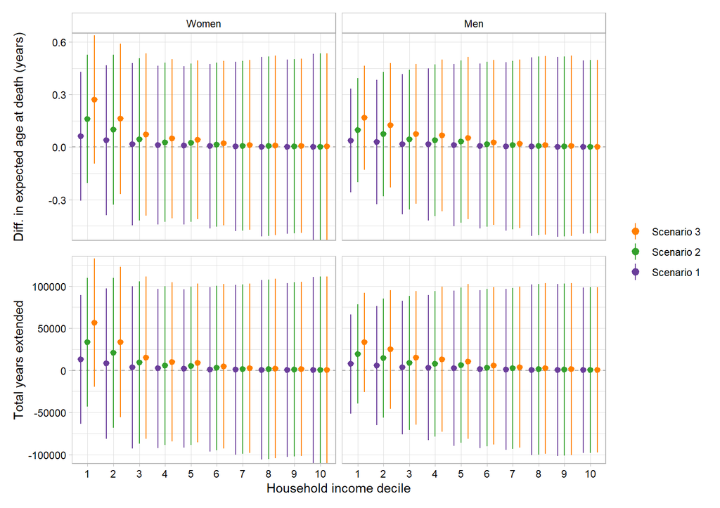

```r
#decile point estimates
deciles <- point_ests_plots()

#plot
p1 <- plot_deciles_est()
p2 <- plot_deciles_tot()

p1 + p2 + plot_layout(guides = "collect", nrow=2) & theme(legend.position = "right", legend.title=element_blank()) & guides(color=guide_legend(reverse=T), fill=guide_legend(reverse=T))
```

```r
ggsave('appendix_3d.png', height=6, width=8.5, dpi=600)
```

## 5.3 Modifying strength of income-mortality relationship

Effects of scenarios if we assume income only affects expected age at death for 1/2 of respondents (i.e., we keep 1/2 of respondents’ incomes as observed in the data rather than returning their stolen wages)

```r
#7 spline knots since underlying data are based on over a billion observations
knots_7 <- as.numeric(quantile(chetty$hh_inc, c(.025, .1833, .3417, .5, .6583, .8167, .975)))

#fit models to Chetty data to interpolate across chunky income values and smooth across random dips
fit <- lm(le_raceadj ~ rcs(hh_inc, parms=knots_7)*gnd, data=chetty, w=count)

#create large expanded Chetty dataset -> we'll use this to get weighed average estimates for our various scenarios
data.frame(pctile=rep(chetty$pctile, chetty$count/1000),
           hh_inc=rep(chetty$hh_inc, chetty$count/1000),
           hh_inc_cat=rep(chetty$hh_inc_cat, chetty$count/1000),
           prop_theft=rep(chetty$prop_theft, chetty$count/1000),
           yr_theft=rep(chetty$yr_theft, chetty$count/1000),
           gnd=rep(chetty$gnd, chetty$count/1000),
           sd=rep(chetty$sd_le_raceadj, chetty$count/1000),
           ACS_pop=rep(chetty$ACS_pop, chetty$count/1000)) %>%
  mutate(id=row_number()) -> chetty_tot

#predict expected age at death using fitted model and observed income values in expanded Chetty data
obs <- cbind(chetty_tot, data.frame(sim_1=predict(fit, newdata = chetty_tot, type="response")), data.frame(type="Observed"))

#simulate expected age at death under hypothetical scenarios
int1 <- int_func_primary(prop=1/2, inc=1, scenario="Scenario 1: 1/2")
int2 <- int_func_primary(prop=2/2, inc=1, scenario="Scenario 1: 2/2")
int3 <- int_func_primary(prop=1/2*(68/26), inc=1, scenario="Scenario 2: 1/2")
int4 <- int_func_primary(prop=2/2*(68/26), inc=1, scenario="Scenario 2: 2/2")
int5 <- int_func_primary(prop=1/2*(68/26), inc=(1/0.58), scenario="Scenario 3: 1/2")
int6 <- int_func_primary(prop=2/2*(68/26), inc=(1/0.58), scenario="Scenario 3: 2/2")

#bind together
binded <- rbind(obs, int1, int2, int3, int4, int5, int6)
```

### 5.3.1 Point estimates

```r
#point estimates for difference in mean expected age at death across scenarios
overall <- point_ests(pctiled1=100, pctiled2=1, rooted=100, fractioned=1)

#point estimates for difference in mean expected age at death across scenarios within affected group
affected <- point_ests(pctiled1=10, pctiled2=1, rooted=10, fractioned=0.1)

#point estimates for difference in mean expected age at death across scenarios within unaffected group
unaffected <- point_ests(pctiled1=100, pctiled2=91, rooted=10, fractioned=0.1)

#DiD ests
did <- did_ests()

#print point ests
kable(rbind(overall, affected, unaffected), digits=c(2,2,2,2,2,2,2,2,0,0,0), format.args = list(big.mark = ",", scientific = FALSE),
      col.names=c("", "Scenario", "Estimate", "Lower", "Upper", "Estimate", "Lower", "Upper", "Estimate", "Lower", "Upper")) %>%
  kable_styling("striped") %>%
  add_header_above(c(" "=2, "Mean expected age at death"=3, "Diff in expected age at death"=3, "Total years extended"=3)) %>%
  group_rows("Overall", 1, 14) %>%
  group_rows("Lower HH income decile", 15, 28) %>%
  group_rows("Upper HH income decile", 29, 42)
```

|  | Scenario | Mean expected age at death Estimate | Mean expected age at death Lower | Mean expected age at death Upper | Diff in expected age at death Estimate | Diff in expected age at death Lower | Diff in expected age at death Upper | Total years extended Estimate | Total years extended Lower | Total years extended Upper |
| --- | --- | --- | --- | --- | --- | --- | --- | --- | --- | --- |
| **Overall** |  |  |  |  |  |  |  |  |  |  |
| Women | Observed | 84.93 | 84.91 | 84.95 | 0.00 | -0.02 | 0.02 | 0 | -696,558 | 696,558 |
| Women | Scenario 1: 1/2 | 84.94 | 84.92 | 84.95 | 0.01 | -0.02 | 0.03 | 166,571 | -529,987 | 863,130 |
| Women | Scenario 1: 2/2 | 84.94 | 84.93 | 84.96 | 0.01 | -0.01 | 0.03 | 333,163 | -363,395 | 1,029,721 |
| Women | Scenario 2: 1/2 | 84.94 | 84.93 | 84.96 | 0.01 | -0.01 | 0.04 | 435,454 | -261,104 | 1,132,013 |
| Women | Scenario 2: 2/2 | 84.96 | 84.94 | 84.97 | 0.03 | 0.01 | 0.05 | 871,072 | 174,513 | 1,567,630 |
| Women | Scenario 3: 1/2 | 84.95 | 84.94 | 84.97 | 0.02 | 0.00 | 0.05 | 735,725 | 39,167 | 1,432,283 |
| Women | Scenario 3: 2/2 | 84.98 | 84.96 | 84.99 | 0.05 | 0.02 | 0.07 | 1,471,717 | 775,159 | 2,168,275 |
| Men | Observed | 81.28 | 81.27 | 81.30 | 0.00 | -0.02 | 0.02 | 0 | -593,409 | 593,409 |
| Men | Scenario 1: 1/2 | 81.29 | 81.27 | 81.30 | 0.00 | -0.01 | 0.02 | 147,206 | -446,203 | 740,614 |
| Men | Scenario 1: 2/2 | 81.29 | 81.28 | 81.30 | 0.01 | -0.01 | 0.03 | 294,502 | -298,906 | 887,911 |
| Men | Scenario 2: 1/2 | 81.29 | 81.28 | 81.31 | 0.01 | -0.01 | 0.03 | 385,110 | -208,299 | 978,519 |
| Men | Scenario 2: 2/2 | 81.31 | 81.29 | 81.32 | 0.02 | 0.01 | 0.04 | 770,457 | 177,048 | 1,363,866 |
| Men | Scenario 3: 1/2 | 81.30 | 81.29 | 81.32 | 0.02 | 0.00 | 0.04 | 658,527 | 65,118 | 1,251,936 |
| Men | Scenario 3: 2/2 | 81.32 | 81.31 | 81.34 | 0.04 | 0.02 | 0.06 | 1,317,428 | 724,019 | 1,910,837 |
| **Lower HH income decile** |  |  |  |  |  |  |  |  |  |  |
| Women | Observed | 81.16 | 81.12 | 81.20 | 0.00 | -0.06 | 0.06 | 0 | -182,668 | 182,668 |
| Women | Scenario 1: 1/2 | 81.18 | 81.14 | 81.22 | 0.02 | -0.04 | 0.08 | 59,858 | -122,809 | 242,526 |
| Women | Scenario 1: 2/2 | 81.20 | 81.16 | 81.24 | 0.04 | -0.02 | 0.10 | 119,848 | -62,819 | 302,516 |
| Women | Scenario 2: 1/2 | 81.21 | 81.17 | 81.25 | 0.05 | -0.01 | 0.11 | 155,773 | -26,894 | 338,441 |
| Women | Scenario 2: 2/2 | 81.26 | 81.22 | 81.30 | 0.10 | 0.04 | 0.16 | 309,916 | 127,248 | 492,583 |
| Women | Scenario 3: 1/2 | 81.25 | 81.21 | 81.29 | 0.08 | 0.03 | 0.14 | 265,729 | 83,061 | 448,396 |
| Women | Scenario 3: 2/2 | 81.33 | 81.29 | 81.37 | 0.17 | 0.11 | 0.22 | 528,685 | 346,018 | 711,353 |
| Men | Observed | 75.48 | 75.44 | 75.51 | 0.00 | -0.05 | 0.05 | 0 | -150,872 | 150,872 |
| Men | Scenario 1: 1/2 | 75.49 | 75.46 | 75.52 | 0.01 | -0.04 | 0.06 | 41,751 | -109,121 | 192,624 |
| Men | Scenario 1: 2/2 | 75.50 | 75.47 | 75.54 | 0.03 | -0.02 | 0.08 | 84,130 | -66,742 | 235,003 |
| Men | Scenario 2: 1/2 | 75.51 | 75.48 | 75.55 | 0.04 | -0.01 | 0.08 | 109,777 | -41,096 | 260,649 |
| Men | Scenario 2: 2/2 | 75.55 | 75.51 | 75.58 | 0.07 | 0.02 | 0.12 | 220,652 | 69,780 | 371,524 |
| Men | Scenario 3: 1/2 | 75.54 | 75.50 | 75.57 | 0.06 | 0.01 | 0.11 | 189,304 | 38,431 | 340,176 |
| Men | Scenario 3: 2/2 | 75.60 | 75.57 | 75.63 | 0.12 | 0.07 | 0.17 | 380,502 | 229,630 | 531,374 |
| **Upper HH income decile** |  |  |  |  |  |  |  |  |  |  |
| Women | Observed | 88.29 | 88.23 | 88.35 | 0.00 | -0.09 | 0.09 | 0 | -269,771 | 269,771 |
| Women | Scenario 1: 1/2 | 88.29 | 88.23 | 88.35 | 0.00 | -0.08 | 0.09 | 1,001 | -268,769 | 270,772 |
| Women | Scenario 1: 2/2 | 88.29 | 88.23 | 88.35 | 0.00 | -0.08 | 0.09 | 1,995 | -267,775 | 271,766 |
| Women | Scenario 2: 1/2 | 88.29 | 88.23 | 88.35 | 0.00 | -0.08 | 0.09 | 2,512 | -267,258 | 272,283 |
| Women | Scenario 2: 2/2 | 88.29 | 88.23 | 88.35 | 0.00 | -0.08 | 0.09 | 5,088 | -264,683 | 274,859 |
| Women | Scenario 3: 1/2 | 88.29 | 88.23 | 88.35 | 0.00 | -0.08 | 0.09 | 4,256 | -265,514 | 274,027 |
| Women | Scenario 3: 2/2 | 88.29 | 88.23 | 88.35 | 0.00 | -0.08 | 0.09 | 8,622 | -261,149 | 278,392 |
| Men | Observed | 86.35 | 86.30 | 86.40 | 0.00 | -0.07 | 0.07 | 0 | -228,262 | 228,262 |
| Men | Scenario 1: 1/2 | 86.35 | 86.30 | 86.40 | 0.00 | -0.07 | 0.07 | 811 | -227,451 | 229,073 |
| Men | Scenario 1: 2/2 | 86.35 | 86.30 | 86.40 | 0.00 | -0.07 | 0.07 | 1,641 | -226,620 | 229,903 |
| Men | Scenario 2: 1/2 | 86.35 | 86.30 | 86.40 | 0.00 | -0.07 | 0.07 | 2,152 | -226,109 | 230,414 |
| Men | Scenario 2: 2/2 | 86.35 | 86.30 | 86.40 | 0.00 | -0.07 | 0.08 | 4,314 | -223,948 | 232,576 |
| Men | Scenario 3: 1/2 | 86.35 | 86.30 | 86.40 | 0.00 | -0.07 | 0.08 | 3,644 | -224,618 | 231,906 |
| Men | Scenario 3: 2/2 | 86.35 | 86.30 | 86.41 | 0.00 | -0.07 | 0.08 | 7,304 | -220,957 | 235,566 |

```r
#print did
kable(did, digits=c(2,2,2,2,2,0,0,0), format.args = list(big.mark = ",", scientific = FALSE),
      col.names=c("", "Scenario", "Estimate", "Lower", "Upper", "Estimate", "Lower", "Upper")) %>%
  kable_styling("striped") %>%
  add_header_above(c(" "=2, "DiD in expected age at death"=3, "DiD in years extended"=3))
```

|  | Scenario | DiD in expected age at death Estimate | DiD in expected age at death Lower | DiD in expected age at death Upper | DiD in years extended Estimate | DiD in years extended Lower | DiD in years extended Upper |
| --- | --- | --- | --- | --- | --- | --- | --- |
| Women | Scenario 1: 1/2 | 0.02 | -0.08 | 0.12 | 58,857 | -266,940 | 384,654 |
| Women | Scenario 1: 2/2 | 0.04 | -0.07 | 0.14 | 117,853 | -207,944 | 443,650 |
| Women | Scenario 2: 1/2 | 0.05 | -0.05 | 0.15 | 153,261 | -172,536 | 479,058 |
| Women | Scenario 2: 2/2 | 0.10 | -0.01 | 0.20 | 304,828 | -20,969 | 630,625 |
| Women | Scenario 3: 1/2 | 0.08 | -0.02 | 0.19 | 261,472 | -64,325 | 587,269 |
| Women | Scenario 3: 2/2 | 0.16 | 0.06 | 0.27 | 520,064 | 194,267 | 845,861 |
| Men | Scenario 1: 1/2 | 0.01 | -0.08 | 0.10 | 40,940 | -232,676 | 314,556 |
| Men | Scenario 1: 2/2 | 0.03 | -0.06 | 0.12 | 82,489 | -191,127 | 356,105 |
| Men | Scenario 2: 1/2 | 0.03 | -0.05 | 0.12 | 107,624 | -165,992 | 381,241 |
| Men | Scenario 2: 2/2 | 0.07 | -0.02 | 0.16 | 216,338 | -57,278 | 489,955 |
| Men | Scenario 3: 1/2 | 0.06 | -0.03 | 0.15 | 185,660 | -87,957 | 459,276 |
| Men | Scenario 3: 2/2 | 0.12 | 0.03 | 0.21 | 373,198 | 99,581 | 646,814 |

### 5.3.2 Plots

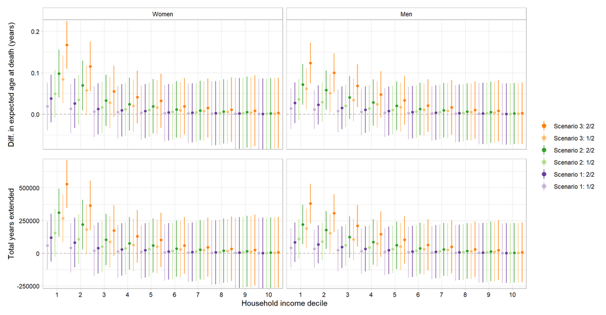

```r
#decile point estimates
deciles <- point_ests_plots()

#plot
p1 <- plot_deciles_est(vals=c("#CAB2D6", "#6A3D9A", "#B2DF8A", "#33A02C", "#FDBF6F", "#FF7F00"), fattened=2, widthed=1.0)
p2 <- plot_deciles_tot(vals=c("#CAB2D6", "#6A3D9A", "#B2DF8A", "#33A02C", "#FDBF6F", "#FF7F00"), fattened=2, widthed=1.0)

p1 + p2 + plot_layout(guides = "collect", nrow=2) & theme(legend.position = "right", legend.title=element_blank()) & guides(color=guide_legend(reverse=T), fill=guide_legend(reverse=T))
```

```r
ggsave('appendix_4c.png', height=6.25, width=12, dpi=600)
```

## 5.4 Inequity in expected age at death in tenth versus first income deciles by year

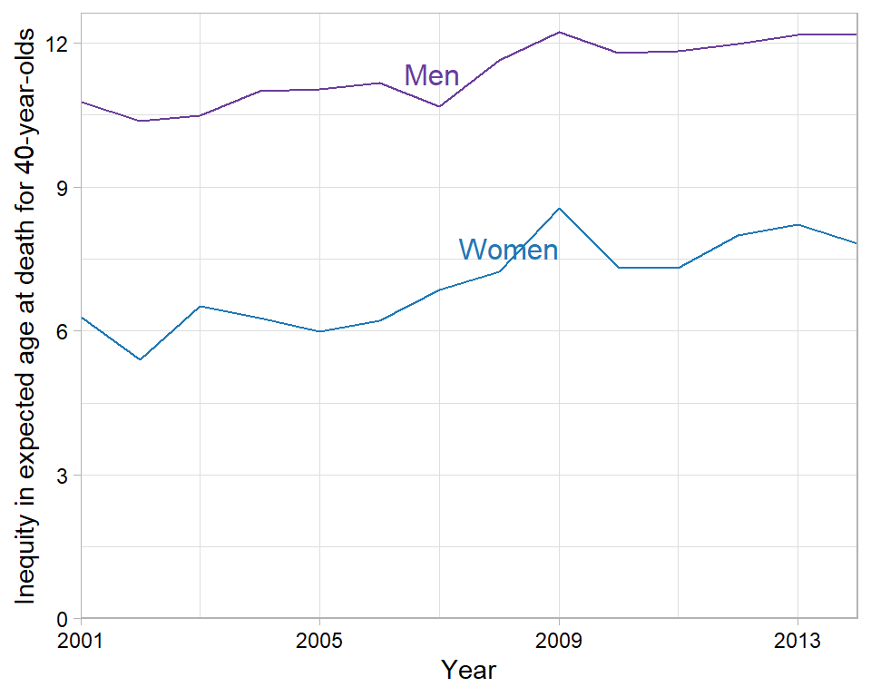

```r
chetty_annual %>%
  mutate(d1_d10=ifelse(pctile<=10, "d1",
                      ifelse(pctile>90, "d10", "other"))) %>%
  filter(d1_d10 != "other") %>%
  group_by(year, d1_d10, gnd) %>%
  summarise(meaned=weighted.mean(le_raceadj, w=count)) %>%
  arrange(year, gnd, d1_d10) %>%
  group_by(year, gnd) %>%
  mutate(diff=meaned-lag(meaned)) %>%
  filter(d1_d10=="d10") -> change_over_time

#plot
ggplot(change_over_time, aes(x=year, y=diff, group=gnd, color=gnd, label=gnd, fill=gnd)) +
  geom_line() +
  geom_dl(method='smart.grid') +
  scale_color_manual(values=c("#1F78B4", "#6A3D9A")) +
  scale_fill_manual(values=c("#1F78B4", "#6A3D9A")) +
  ylab("Inequity in expected age at death for 40-year-olds") +
  xlab("Year") +
  scale_y_continuous(breaks=c(0, 3, 6, 9, 12), limits=c(0, 12.5), expand=expansion(mult=c(0.0,0.01))) +
  scale_x_continuous(breaks=c(2001, 2005, 2009, 2013), expand=expansion(mult=c(0.0,0.0))) +
  theme_light() +
  theme(legend.position="none", axis.text.x=element_text(color="black"), axis.text.y=element_text(color="black"))
```

```r
ggsave("appendix_5.png", height=4, width=5, dpi=600)
```

## 5.5 City-specific estimates

```r
#load national and msa-level chetty data
chetty_nat <- read.csv(here('health_ineq_online_table_1.csv'))
read.csv(here('health_ineq_online_table_7.csv')) %>%
  filter(czname %in% c('Detroit', 'New York City')) %>%
  select(c(2, seq(8,164,2), 166:206)) -> chetty_msa

#calculate mean income by ventile across years so that we can fit wage theft models - these match published estimates in Chetty paper presented in Figure 4
chetty_nat %>%
  mutate(pctile=ntile(pctile, 20)) %>%
  group_by(gnd, pctile) %>%
  summarise(hh_inc=weighted.mean(hh_inc, w=count)) %>%
  mutate(gnd=factor(ifelse(gnd=="M", "Men", "Women"), c("Women", "Men"))) -> chetty_nat_summed

#make chetty msa data long
chetty_msa %>%
  pivot_longer(cols=-1) %>%
  mutate(variable=ifelse(substr(name, 1, 5)=="count", "count",
                      ifelse(substr(name, 1, 2)=="le", "le_raceadj",
                             ifelse(substr(name, 1, 2)=="sd", "sd_le_raceadj", NA))),
         gnd=factor(ifelse(str_sub(name, -2, -1)=="_F", "Women", "Men"), c("Women", "Men")),
         pctile=as.numeric(ifelse(str_sub(name, -4, -4)=="v", str_sub(name, -3, -3),
                                  ifelse(str_sub(name, -5, -5)=="v", str_sub(name, -4, -3), "error")))) %>%
  select(-"name") %>%
  pivot_wider(names_from=variable, values_from=value) -> chetty_msa_long

#merge msa and national data to get hh_income values
chetty_msa_long <- merge(chetty_msa_long, chetty_nat_summed, by=c('gnd', 'pctile'))

#make categorical income variable for merging Chetty and EPI data; make state variable for same purpose
chetty_msa_long %>%
  mutate(hh_inc=hh_inc*(352.6/337.3), #adjust Chetty estimates to 2016 dollars from 2012 dollars using CPI-U-RS (Chetty estimates in 2012 dollars, EPI estimates in 2016??)
         hh_inc_cat=ifelse(hh_inc<10000, "<10000",
                           ifelse(hh_inc>=10000 & hh_inc<25000, "10000-24999",
                                  ifelse(hh_inc>=25000 & hh_inc<40000, "25000-39999",
                                         ifelse(hh_inc>=40000 & hh_inc<60000, "40000-59999",
                                                ifelse(hh_inc>=60000 & hh_inc<99999, "60000-99999",
                                                       ifelse(hh_inc>=100000 & hh_inc<150000, "100000-149999",
                                                              ifelse(hh_inc>=150000, "150000+", "error"))))))),
         state=ifelse(czname=="Detroit", "Michigan", "New York")) %>%
  arrange(czname, pctile, gnd) -> chetty_msa_long

#merge in ACS data on population counts; MET2013 not available from 2001-2004 so we'll need to extrapolate
fread(here("ACS_IPUMS_2001_2014.csv")) %>%
  filter(YEAR>=2005 & FTOTINC>0 & AGE==40 & (MET2013==19820 | MET2013==35620)) %>%
  mutate(gnd=ifelse(SEX==1, "Men", "Women"),
         czname=ifelse(MET2013==19820, "Detroit", "New York City")) %>%
  group_by(gnd, czname) %>%
  summarise(ACS_pop=(sum(PERWT)/10)*14) %>% #use average annual population to create total 14-year population
  right_join(chetty_msa_long, by=c("gnd", "czname")) -> chetty_msa_long
```

### 5.5.1 Chetty data

#### 5.5.1.1 Sample of data

```r
kable(chetty_msa_long, digits=2, format.args = list(big.mark = ",", scientific = FALSE)) %>%
  kable_styling('striped')  %>%
  scroll_box(width = "100%", height = "500px")
```

| gnd | czname | ACS_pop | pctile | le_raceadj | sd_le_raceadj | count | hh_inc | hh_inc_cat | state |
| --- | --- | --- | --- | --- | --- | --- | --- | --- | --- |
| Men | Detroit | 424,804.8 | 1 | 72.31 | 0.16 | 565,117 | 3,484.79 | <10000 | Michigan |
| Men | Detroit | 424,804.8 | 2 | 74.67 | 0.21 | 477,184 | 11,572.57 | 10000-24999 | Michigan |
| Men | Detroit | 424,804.8 | 3 | 75.08 | 0.22 | 449,411 | 18,619.94 | 10000-24999 | Michigan |
| Men | Detroit | 424,804.8 | 4 | 76.06 | 0.23 | 437,462 | 24,929.93 | 10000-24999 | Michigan |
| Men | Detroit | 424,804.8 | 5 | 76.59 | 0.21 | 454,921 | 30,958.18 | 25000-39999 | Michigan |
| Men | Detroit | 424,804.8 | 6 | 77.64 | 0.21 | 497,407 | 36,921.05 | 25000-39999 | Michigan |
| Men | Detroit | 424,804.8 | 7 | 78.81 | 0.23 | 513,216 | 42,971.00 | 40000-59999 | Michigan |
| Men | Detroit | 424,804.8 | 8 | 80.11 | 0.24 | 499,600 | 49,223.91 | 40000-59999 | Michigan |
| Men | Detroit | 424,804.8 | 9 | 80.33 | 0.24 | 517,071 | 55,735.12 | 40000-59999 | Michigan |
| Men | Detroit | 424,804.8 | 10 | 81.01 | 0.24 | 544,995 | 62,574.17 | 60000-99999 | Michigan |
| Men | Detroit | 424,804.8 | 11 | 81.22 | 0.25 | 586,571 | 69,837.05 | 60000-99999 | Michigan |
| Men | Detroit | 424,804.8 | 12 | 81.62 | 0.24 | 627,309 | 77,588.62 | 60000-99999 | Michigan |
| Men | Detroit | 424,804.8 | 13 | 82.03 | 0.24 | 666,394 | 85,954.88 | 60000-99999 | Michigan |
| Men | Detroit | 424,804.8 | 14 | 82.31 | 0.24 | 703,318 | 95,187.76 | 60000-99999 | Michigan |
| Men | Detroit | 424,804.8 | 15 | 82.92 | 0.24 | 741,227 | 105,705.09 | 100000-149999 | Michigan |
| Men | Detroit | 424,804.8 | 16 | 83.33 | 0.23 | 781,280 | 118,299.44 | 100000-149999 | Michigan |
| Men | Detroit | 424,804.8 | 17 | 84.04 | 0.23 | 822,319 | 134,838.69 | 100000-149999 | Michigan |
| Men | Detroit | 424,804.8 | 18 | 84.61 | 0.23 | 841,779 | 159,675.27 | 150000+ | Michigan |
| Men | Detroit | 424,804.8 | 19 | 85.74 | 0.24 | 768,715 | 207,997.33 | 150000+ | Michigan |
| Men | Detroit | 424,804.8 | 20 | 86.53 | 0.28 | 604,959 | 713,855.36 | 150000+ | Michigan |
| Men | New York City | 2,170,224.0 | 1 | 78.65 | 0.19 | 1,325,532 | 3,484.79 | <10000 | New York |
| Men | New York City | 2,170,224.0 | 2 | 80.20 | 0.20 | 1,724,619 | 11,572.57 | 10000-24999 | New York |
| Men | New York City | 2,170,224.0 | 3 | 79.74 | 0.19 | 1,513,161 | 18,619.94 | 10000-24999 | New York |
| Men | New York City | 2,170,224.0 | 4 | 79.49 | 0.21 | 1,300,434 | 24,929.93 | 10000-24999 | New York |
| Men | New York City | 2,170,224.0 | 5 | 79.84 | 0.21 | 1,180,190 | 30,958.18 | 25000-39999 | New York |
| Men | New York City | 2,170,224.0 | 6 | 79.99 | 0.21 | 1,140,317 | 36,921.05 | 25000-39999 | New York |
| Men | New York City | 2,170,224.0 | 7 | 80.17 | 0.20 | 1,126,482 | 42,971.00 | 40000-59999 | New York |
| Men | New York City | 2,170,224.0 | 8 | 80.93 | 0.19 | 1,114,268 | 49,223.91 | 40000-59999 | New York |
| Men | New York City | 2,170,224.0 | 9 | 81.05 | 0.21 | 1,064,360 | 55,735.12 | 40000-59999 | New York |
| Men | New York City | 2,170,224.0 | 10 | 81.22 | 0.21 | 1,015,647 | 62,574.17 | 60000-99999 | New York |
| Men | New York City | 2,170,224.0 | 11 | 81.62 | 0.22 | 980,099 | 69,837.05 | 60000-99999 | New York |
| Men | New York City | 2,170,224.0 | 12 | 82.01 | 0.21 | 968,012 | 77,588.62 | 60000-99999 | New York |
| Men | New York City | 2,170,224.0 | 13 | 82.36 | 0.21 | 967,962 | 85,954.88 | 60000-99999 | New York |
| Men | New York City | 2,170,224.0 | 14 | 82.98 | 0.22 | 976,563 | 95,187.76 | 60000-99999 | New York |
| Men | New York City | 2,170,224.0 | 15 | 82.75 | 0.22 | 1,010,321 | 105,705.09 | 100000-149999 | New York |
| Men | New York City | 2,170,224.0 | 16 | 84.05 | 0.21 | 1,066,922 | 118,299.44 | 100000-149999 | New York |
| Men | New York City | 2,170,224.0 | 17 | 84.27 | 0.20 | 1,167,948 | 134,838.69 | 100000-149999 | New York |
| Men | New York City | 2,170,224.0 | 18 | 85.08 | 0.20 | 1,321,784 | 159,675.27 | 150000+ | New York |
| Men | New York City | 2,170,224.0 | 19 | 86.26 | 0.18 | 1,517,700 | 207,997.33 | 150000+ | New York |
| Men | New York City | 2,170,224.0 | 20 | 87.47 | 0.15 | 2,012,753 | 713,855.36 | 150000+ | New York |
| Women | Detroit | 471,021.6 | 1 | 78.43 | 0.21 | 635,307 | 3,899.09 | <10000 | Michigan |
| Women | Detroit | 471,021.6 | 2 | 80.08 | 0.25 | 565,248 | 11,603.29 | 10000-24999 | Michigan |
| Women | Detroit | 471,021.6 | 3 | 80.63 | 0.26 | 530,171 | 17,483.35 | 10000-24999 | Michigan |
| Women | Detroit | 471,021.6 | 4 | 81.33 | 0.26 | 524,512 | 22,748.60 | 10000-24999 | Michigan |
| Women | Detroit | 471,021.6 | 5 | 81.56 | 0.25 | 547,935 | 27,880.83 | 25000-39999 | Michigan |
| Women | Detroit | 471,021.6 | 6 | 82.86 | 0.27 | 582,893 | 33,082.02 | 25000-39999 | Michigan |
| Women | Detroit | 471,021.6 | 7 | 83.24 | 0.26 | 602,700 | 38,476.07 | 25000-39999 | Michigan |
| Women | Detroit | 471,021.6 | 8 | 83.88 | 0.26 | 606,096 | 44,206.47 | 40000-59999 | Michigan |
| Women | Detroit | 471,021.6 | 9 | 84.26 | 0.26 | 596,272 | 50,334.56 | 40000-59999 | Michigan |
| Women | Detroit | 471,021.6 | 10 | 84.58 | 0.27 | 600,437 | 56,872.16 | 40000-59999 | Michigan |
| Women | Detroit | 471,021.6 | 11 | 85.08 | 0.26 | 618,245 | 63,906.10 | 60000-99999 | Michigan |
| Women | Detroit | 471,021.6 | 12 | 85.61 | 0.27 | 643,413 | 71,511.02 | 60000-99999 | Michigan |
| Women | Detroit | 471,021.6 | 13 | 85.37 | 0.26 | 669,652 | 79,753.71 | 60000-99999 | Michigan |
| Women | Detroit | 471,021.6 | 14 | 86.02 | 0.26 | 692,406 | 88,866.55 | 60000-99999 | Michigan |
| Women | Detroit | 471,021.6 | 15 | 86.11 | 0.26 | 720,642 | 99,244.66 | 60000-99999 | Michigan |
| Women | Detroit | 471,021.6 | 16 | 86.23 | 0.27 | 758,022 | 111,598.34 | 100000-149999 | Michigan |
| Women | Detroit | 471,021.6 | 17 | 86.77 | 0.26 | 804,397 | 127,621.41 | 100000-149999 | Michigan |
| Women | Detroit | 471,021.6 | 18 | 86.95 | 0.25 | 845,592 | 151,474.37 | 150000+ | Michigan |
| Women | Detroit | 471,021.6 | 19 | 87.73 | 0.26 | 795,380 | 197,027.66 | 150000+ | Michigan |
| Women | Detroit | 471,021.6 | 20 | 88.64 | 0.27 | 625,989 | 682,507.16 | 150000+ | Michigan |
| Women | New York City | 2,264,326.4 | 1 | 83.60 | 0.20 | 1,492,820 | 3,899.09 | <10000 | New York |
| Women | New York City | 2,264,326.4 | 2 | 84.56 | 0.23 | 1,821,480 | 11,603.29 | 10000-24999 | New York |
| Women | New York City | 2,264,326.4 | 3 | 83.97 | 0.24 | 1,511,591 | 17,483.35 | 10000-24999 | New York |
| Women | New York City | 2,264,326.4 | 4 | 84.02 | 0.25 | 1,325,789 | 22,748.60 | 10000-24999 | New York |
| Women | New York City | 2,264,326.4 | 5 | 84.36 | 0.25 | 1,262,199 | 27,880.83 | 25000-39999 | New York |
| Women | New York City | 2,264,326.4 | 6 | 84.23 | 0.25 | 1,289,141 | 33,082.02 | 25000-39999 | New York |
| Women | New York City | 2,264,326.4 | 7 | 84.53 | 0.24 | 1,338,056 | 38,476.07 | 25000-39999 | New York |
| Women | New York City | 2,264,326.4 | 8 | 84.57 | 0.23 | 1,316,210 | 44,206.47 | 40000-59999 | New York |
| Women | New York City | 2,264,326.4 | 9 | 84.79 | 0.21 | 1,255,869 | 50,334.56 | 40000-59999 | New York |
| Women | New York City | 2,264,326.4 | 10 | 84.42 | 0.22 | 1,177,829 | 56,872.16 | 40000-59999 | New York |
| Women | New York City | 2,264,326.4 | 11 | 84.94 | 0.23 | 1,106,058 | 63,906.10 | 60000-99999 | New York |
| Women | New York City | 2,264,326.4 | 12 | 85.31 | 0.23 | 1,066,627 | 71,511.02 | 60000-99999 | New York |
| Women | New York City | 2,264,326.4 | 13 | 85.21 | 0.23 | 1,063,563 | 79,753.71 | 60000-99999 | New York |
| Women | New York City | 2,264,326.4 | 14 | 85.32 | 0.24 | 1,072,132 | 88,866.55 | 60000-99999 | New York |
| Women | New York City | 2,264,326.4 | 15 | 86.08 | 0.23 | 1,098,558 | 99,244.66 | 60000-99999 | New York |
| Women | New York City | 2,264,326.4 | 16 | 86.23 | 0.23 | 1,151,116 | 111,598.34 | 100000-149999 | New York |
| Women | New York City | 2,264,326.4 | 17 | 86.70 | 0.22 | 1,228,145 | 127,621.41 | 100000-149999 | New York |
| Women | New York City | 2,264,326.4 | 18 | 87.00 | 0.22 | 1,361,812 | 151,474.37 | 150000+ | New York |
| Women | New York City | 2,264,326.4 | 19 | 88.35 | 0.20 | 1,573,672 | 197,027.66 | 150000+ | New York |
| Women | New York City | 2,264,326.4 | 20 | 88.80 | 0.18 | 2,025,577 | 682,507.16 | 150000+ | New York |

#### 5.5.1.2 Observed relationship between income and expected age at death

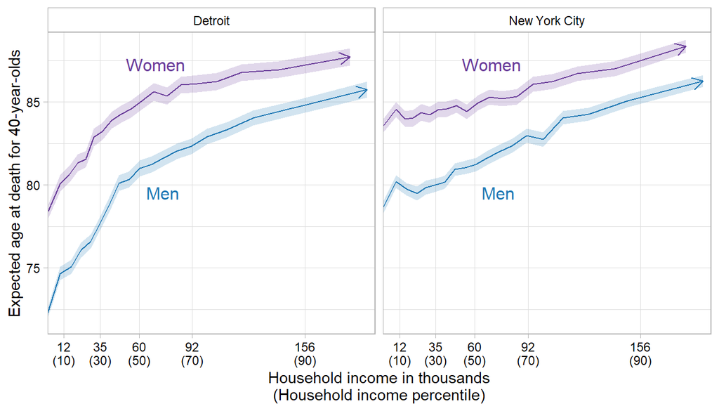

```r
#labels
xlabels <- c("12\n(10)", "35\n(30)", "60\n(50)", "92\n(70)", "156\n(90)")

ggplot(subset(chetty_msa_long, hh_inc<215000), aes(x=hh_inc, y=le_raceadj, group=gnd, color=gnd, label=gnd, fill=gnd)) +
  facet_wrap(~czname) +
  geom_line(arrow = arrow(length=unit(0.30,"cm"), ends="last", type = "open")) +
  geom_ribbon(aes(ymin=le_raceadj-1.96*sd_le_raceadj, ymax=le_raceadj+1.96*sd_le_raceadj), alpha=0.2, lty=0) +
  geom_dl(method='smart.grid') +
  scale_color_manual(values=c("#1F78B4", "#6A3D9A")) +
  scale_fill_manual(values=c("#1F78B4", "#6A3D9A")) +
  ylab("Expected age at death for 40-year-olds") +
  xlab("Household income in thousands\n(Household income percentile)") +
  scale_y_continuous(limits=c(71, 89), expand=expansion(mult=c(0.0,0.01))) +
  scale_x_continuous(breaks=c(14000, 37000, 62000, 96000, 168000), labels=xlabels, minor_breaks=NULL, expand=expansion(mult=c(0,0.025))) +
  theme_light() +
  theme(legend.position="none", strip.background=element_rect(color="darkgrey", fill=NA), strip.text=element_text(color="black"),
        axis.text.x=element_text(color="black"), axis.text.y=element_text(color="black"))
```

### 5.5.2 EPI data on MW violations

```r
#######calculate prevalence separately by state, since gender composition of MW earners varies by state
###michigan
#data on wage theft by income and state, with state-level ratio of theft prevalence among women vs men
theft <- subset(read.csv(here('epi_data_states.csv'), fileEncoding="UTF-8-BOM"), state=="Michigan")

#estimate prevalence of theft among women and men within each income category and state using simultaneous equations
binded <- NULL
for(i in 1:length(theft$gnd_ratio_state)){
  fn <- function(x){
    eq1 <- x[1]/x[2] - theft$gnd_ratio_state[i]
    eq2 <- (0.466*x[1] + 0.534*x[2]) -  theft$prop_theft[i]
    return(c(eq1, eq2))
  }
  binded <- rbind(binded, nleqslv(c(1,5), fn)$x)
}

mich <- rbind(data.frame(state=theft$state, hh_inc_cat=theft$hh_inc_cat, prop_theft=binded[,1], yr_theft=theft$yr_theft, gnd="Women"),
               data.frame(state=theft$state, hh_inc_cat=theft$hh_inc_cat, prop_theft=binded[,2], yr_theft=theft$yr_theft, gnd="Men"))

###new york
#data on wage theft by income and state, with state-level ratio of theft prevalence among women vs men
theft <- subset(read.csv(here('epi_data_states.csv'), fileEncoding="UTF-8-BOM"), state=="New York")

#estimate prevalence of theft among women and men within each income category and state using simultaneous equations
binded <- NULL
for(i in 1:length(theft$gnd_ratio_state)){
  fn <- function(x){
    eq1 <- x[1]/x[2] - theft$gnd_ratio_state[i]
    eq2 <- (0.471*x[1] + 0.529*x[2]) -  theft$prop_theft[i]
    return(c(eq1, eq2))
  }
  binded <- rbind(binded, nleqslv(c(1,5), fn)$x)
}

#stack states together
rbind(mich, rbind(data.frame(state=theft$state, hh_inc_cat=theft$hh_inc_cat, prop_theft=binded[,1], yr_theft=theft$yr_theft, gnd="Women"),
                        data.frame(state=theft$state, hh_inc_cat=theft$hh_inc_cat, prop_theft=binded[,2], yr_theft=theft$yr_theft, gnd="Men"))) %>%
  mutate(hh_inc_cat=factor(hh_inc_cat, c("<10000", '10000-24999', '25000-39999', '40000-59999', '60000-99999', '100000-149999', '150000+'))) -> theft

#print
kable(theft %>% arrange(state, desc(gnd), hh_inc_cat), digits=2, format.args = list(big.mark = ",", scientific = FALSE)) %>%
  kable_styling("striped") %>%
  scroll_box(width = "100%", height = "500px")
```

| state | hh_inc_cat | prop_theft | yr_theft | gnd |
| --- | --- | --- | --- | --- |
| Michigan | <10000 | 0.12 | 3,300 | Women |
| Michigan | 10000-24999 | 0.10 | 3,900 | Women |
| Michigan | 25000-39999 | 0.08 | 3,300 | Women |
| Michigan | 40000-59999 | 0.06 | 3,700 | Women |
| Michigan | 60000-99999 | 0.05 | 3,000 | Women |
| Michigan | 100000-149999 | 0.04 | 2,000 | Women |
| Michigan | 150000+ | 0.03 | 3,300 | Women |
| Michigan | <10000 | 0.07 | 3,300 | Men |
| Michigan | 10000-24999 | 0.05 | 3,900 | Men |
| Michigan | 25000-39999 | 0.04 | 3,300 | Men |
| Michigan | 40000-59999 | 0.03 | 3,700 | Men |
| Michigan | 60000-99999 | 0.03 | 3,000 | Men |
| Michigan | 100000-149999 | 0.02 | 2,000 | Men |
| Michigan | 150000+ | 0.01 | 3,300 | Men |
| New York | <10000 | 0.11 | 4,500 | Women |
| New York | 10000-24999 | 0.09 | 3,000 | Women |
| New York | 25000-39999 | 0.07 | 3,100 | Women |
| New York | 40000-59999 | 0.05 | 3,500 | Women |
| New York | 60000-99999 | 0.04 | 2,900 | Women |
| New York | 100000-149999 | 0.04 | 3,300 | Women |
| New York | 150000+ | 0.03 | 3,300 | Women |
| New York | <10000 | 0.09 | 4,500 | Men |
| New York | 10000-24999 | 0.08 | 3,000 | Men |
| New York | 25000-39999 | 0.06 | 3,100 | Men |
| New York | 40000-59999 | 0.05 | 3,500 | Men |
| New York | 60000-99999 | 0.04 | 2,900 | Men |
| New York | 100000-149999 | 0.03 | 3,300 | Men |
| New York | 150000+ | 0.02 | 3,300 | Men |

```r
#merge the EPI and chetty data
merge(chetty_msa_long, theft, c("hh_inc_cat", "gnd", "state")) -> chetty_msa_long
```

```r
#scenario function
int_func_cz <- function(prop, inc, scenario){ #prop and inc are multipliers for EPI theft cost and prevalence estimates

  #seed
  set.seed(4325)

  #create sample
  chetty_msa_long_tot %>%
    group_by(gnd, hh_inc_cat, czname) %>%
    sample_frac(size=prop_theft*prop, replace=F) %>%
    mutate(hh_inc_rev=hh_inc + inc*yr_theft) %>% #adjusted for inflation (Chetty in 2012 $, EPI estimates from 2013-2015, i.e., 2014 $?)
    ungroup() %>%
    dplyr::select('id', 'hh_inc_rev') -> chetty_samps

  #create hypothetical income variable
  chetty_msa_long_tot %>%
    left_join(chetty_samps, by='id') %>%
    mutate(hh_inc=ifelse(!is.na(hh_inc_rev), hh_inc_rev, hh_inc)) %>%
    dplyr::select(-hh_inc_rev) -> chetty_msa_long_tot_int

  #simulate LE using fitted model and hypothetical income
  int1 <- cbind(chetty_msa_long_tot_int, data.frame(sim_1=predict(fit, newdata = chetty_msa_long_tot_int, type="response")), data.frame(iter=i, type=scenario))
}

#knots at 10th, 50th, and 90th percentiles
knots_3 <- as.numeric(quantile(chetty_msa_long$hh_inc, c(0.1, 0.5, 0.9)))

#fit models to simmed Chetty data, allowing income-LE relationship to vary by gnd, czname, and cz*gender
fit <- lm(le_raceadj ~ rcs(hh_inc, parms=knots_3)*gnd*czname, data=chetty_msa_long, w=count)

#create expanded chetty_msa_long dataset that's size of average annual population
data.frame(czname=rep(chetty_msa_long$czname, chetty_msa_long$count/50),
           pctile=rep(chetty_msa_long$pctile, chetty_msa_long$count/50),
           hh_inc=rep(chetty_msa_long$hh_inc, chetty_msa_long$count/50),
           hh_inc_cat=rep(chetty_msa_long$hh_inc_cat, chetty_msa_long$count/50),
           prop_theft=rep(chetty_msa_long$prop_theft, chetty_msa_long$count/50),
           yr_theft=rep(chetty_msa_long$yr_theft, chetty_msa_long$count/50),
           gnd=rep(chetty_msa_long$gnd, chetty_msa_long$count/50),
           sd=rep(chetty_msa_long$sd_le_raceadj, chetty_msa_long$count/50),
           ACS_pop=rep(chetty_msa_long$ACS_pop, chetty_msa_long$count/50)) %>%
  mutate(id=row_number()) -> chetty_msa_long_tot

#predict LE using fitted model and observed income values in expanded Chetty data
obs <- cbind(chetty_msa_long_tot, data.frame(sim_1=predict(fit, newdata = chetty_msa_long_tot, type="response")), data.frame(iter=i, type="Observed"))

#predict LE under hypothetical scenarios
int1 <- int_func_cz(prop=1, inc=1, scenario="Scenario 1")
int2 <- int_func_cz(prop=(68/26), inc=1, scenario="Scenario 2")
int3 <- int_func_cz(prop=(68/26), inc=(1/0.58), scenario="Scenario 3")

#bind together
binded <- rbind(obs, int1, int2, int3)
```

### 5.5.3 Model output

```r
tidy(fit) %>%
  dplyr::select(c(term, estimate, std.error, p.value)) %>%
  mutate(estimate=ifelse(term=="gndWomen" | term=="(Intercept)" | term=="cznameNew York City" | term=="gndWomen:cznameNew York City", estimate, estimate*1000),
         std.error=ifelse(term=="gndWomen" | term=="(Intercept)" | term=="cznameNew York City" | term=="gndWomen:cznameNew York City", std.error, std.error*1000)) %>%
  kable(digits=2, caption="Income coefficients correspond to effects of changes in 1000s of dollars") %>%
  kable_styling("striped")
```

Income coefficients correspond to effects of changes in 1000s of dollars

| term | estimate | std.error | p.value |
| --- | --- | --- | --- |
| (Intercept) | 72.52 | 0.49 | 0.00 |
| rcs(hh_inc, parms = knots_3)hh_inc | 0.14 | 0.01 | 0.00 |
| rcs(hh_inc, parms = knots_3)hh_inc’ | -0.14 | 0.01 | 0.00 |
| gndWomen | 6.50 | 0.66 | 0.00 |
| cznameNew York City | 5.69 | 0.57 | 0.00 |
| rcs(hh_inc, parms = knots_3)hh_inc:gndWomen | -0.04 | 0.01 | 0.00 |
| rcs(hh_inc, parms = knots_3)hh_inc’:gndWomen | 0.04 | 0.01 | 0.00 |
| rcs(hh_inc, parms = knots_3)hh_inc:cznameNew York City | -0.07 | 0.01 | 0.00 |
| rcs(hh_inc, parms = knots_3)hh_inc’:cznameNew York City | 0.08 | 0.01 | 0.00 |
| gndWomen:cznameNew York City | -1.37 | 0.77 | 0.08 |
| rcs(hh_inc, parms = knots_3)hh_inc:gndWomen:cznameNew York City | 0.01 | 0.01 | 0.38 |
| rcs(hh_inc, parms = knots_3)hh_inc’:gndWomen:cznameNew York City | -0.01 | 0.02 | 0.41 |

```r
glance(fit) %>%
  kable(digits=3) %>%
  kable_styling("striped")
```

| r.squared | adj.r.squared | sigma | statistic | p.value | df | logLik | AIC | BIC | deviance | df.residual | nobs |
| --- | --- | --- | --- | --- | --- | --- | --- | --- | --- | --- | --- |
| 0.961 | 0.955 | 644.735 | 151.863 | 0 | 11 | -77.09 | 180.18 | 211.146 | 28266500 | 68 | 80 |

### 5.5.4 Estimated relationship between income and expected age at death under observed scenario

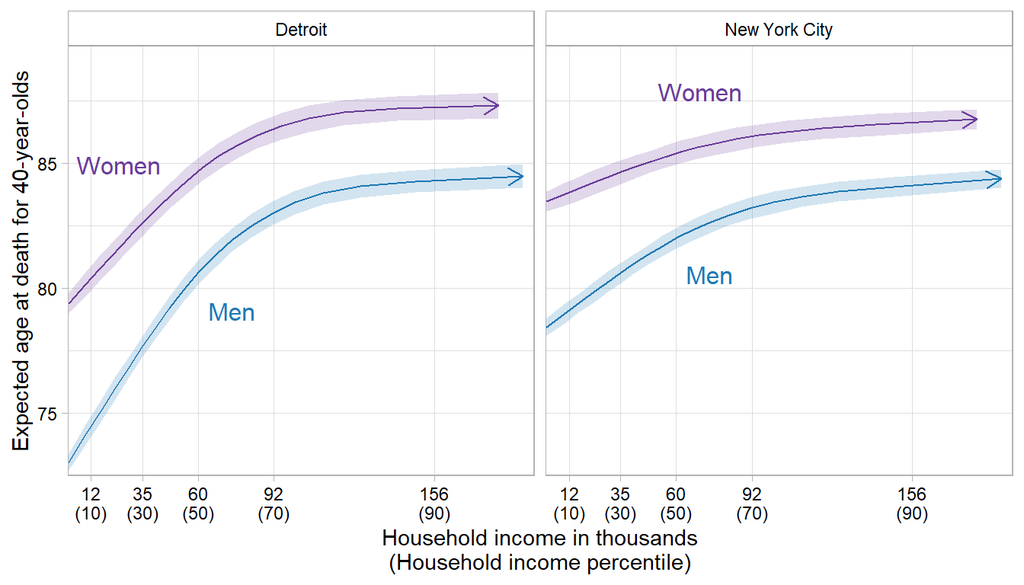

```r
#remove duplicated rows since they're identical for each income level
obs %>%
  filter(!duplicated(paste(gnd, pctile, czname))) -> obs_sub

#labels
xlabels <- c("12\n(10)", "35\n(30)", "60\n(50)", "92\n(70)", "156\n(90)")

ggplot(subset(obs_sub, hh_inc<215000), aes(x=hh_inc, y=sim_1, group=gnd, color=gnd, label=gnd, fill=gnd)) +
  facet_wrap(~czname) +
  geom_line(arrow = arrow(length=unit(0.30,"cm"), ends="last", type = "open")) +
  geom_ribbon(aes(ymin=sim_1 - 1.96 * sd, ymax=sim_1 + 1.96 * sd), alpha=0.2, lty=0) +
  geom_dl(method='smart.grid') +
  scale_color_manual(values=c("#1F78B4", "#6A3D9A")) +
  scale_fill_manual(values=c("#1F78B4", "#6A3D9A")) +
  ylab("Expected age at death for 40-year-olds") +
  xlab("Household income in thousands\n(Household income percentile)") +
  scale_y_continuous(limits=c(72.5, 89.5), expand=expansion(mult=c(0.0,0.01))) +
  scale_x_continuous(breaks=c(14000, 37000, 62000, 96000, 168000), labels=xlabels, minor_breaks=NULL, expand=expansion(mult=c(0,0.025))) +
  theme_light() +
  theme(legend.position="none", strip.background=element_rect(color="darkgrey", fill=NA), strip.text=element_text(color="black"),
        axis.text.x=element_text(color="black"), axis.text.y=element_text(color="black"))
```

```r
ggsave('appendix_6b.png', height=4, width=7, dpi=600)
```

### 5.5.5 Point estimates

```r
#point estimates function
point_ests_cz <- function(pctiled1, pctiled2, rooted, fractioned){
  binded %>%
    filter(pctile<=pctiled1) %>%
    filter(pctile>=pctiled2) %>%
    group_by(type, gnd, czname) %>%
    summarise(meaned=mean(sim_1),
              sdd=mean(sd),
              ACS_pop=mean(ACS_pop)) %>%
    ungroup() %>%
    group_by(gnd, czname) %>%
    mutate(meaned=meaned, #SE for Mean expected age at death is mean SE divided by sqrt of number of SE estimates [mean(SE)/sqrt(number of SE estimates, e.g., 100 in full sample; 10 w/in deciles)]
           meaned_lower=meaned-(1.96 * (sdd/sqrt(rooted))),
           meaned_upper=meaned+(1.96 * (sdd/sqrt(rooted))),
           diff=meaned-first(meaned), #SE for difference in Mean expected age at death is sqrt(2)*[mean(SE)/sqrt(number of SE estimates)] (reduced from formula for SE of diff: sqrt[(SE 1st)^2*(SE 2nd)^2])
           diff_lower=diff-(1.96 * (sqrt(2)*(sdd/sqrt(rooted)))),
           diff_upper=diff+(1.96 * (sqrt(2)*(sdd/sqrt(rooted)))),
           diff_pop=diff*ACS_pop*fractioned,
           diff_lower_pop=diff_lower*ACS_pop*fractioned,
           diff_upper_pop=diff_upper*ACS_pop*fractioned)
}

#DiD function
did_ests <- function(){
  cbind(affected, unaffected)  %>%
    filter(type...1!="Observed") %>%
    right_join(chetty_msa_long[c(1:4),c("ACS_pop", "gnd", "czname")], by=c('gnd...2'='gnd', 'czname...3'='czname'))  %>%
    mutate(se_d1=(diff...9-diff_lower...10)/1.96,
           se_d10=(diff...23-diff_lower...24)/1.96,
           did=diff...9-diff...23,
           did_lower=did-1.96*sqrt(se_d1^2+se_d10^2),
           did_upper=did+1.96*sqrt(se_d1^2+se_d10^2),
           did_pop=did*ACS_pop*0.10,
           did_lower_pop=did_lower*ACS_pop*0.10,
           did_upper_pop=did_upper*ACS_pop*0.10) %>%
    select(czname...3, gnd...2, type...1, did, did_lower, did_upper, did_pop, did_lower_pop, did_upper_pop) %>%
    rename(type=type...1, gnd=gnd...2, czname=czname...3)
}

#point estimates for difference in mean expected age at death across scenarios
point_ests_cz(pctiled1=100, pctiled2=1, rooted=20, fractioned=1) %>% arrange(czname, desc(gnd)) -> overall

#point estimates for difference in mean expected age at death across scenarios within affected group
point_ests_cz(pctiled1=4, pctiled2=1, rooted=4, fractioned=0.2) %>% arrange(czname, desc(gnd)) -> affected

#point estimates for difference in mean expected age at death across scenarios within unaffected group
point_ests_cz(pctiled1=20, pctiled2=17, rooted=4, fractioned=0.2) %>% arrange(czname, desc(gnd)) -> unaffected

#bind all together
rbind(overall, affected, unaffected) %>%
  dplyr::select('czname', 'gnd', 'type', 'meaned', 'meaned_lower', 'meaned_upper', 'diff', 'diff_lower', "diff_upper", 'diff_pop', 'diff_lower_pop', "diff_upper_pop") -> binded_ests

#DiD ests
did_ests() -> did

#print
kable(binded_ests, digits=c(2,2,2,2,2,2,2,2,2,0,0,0), format.args = list(big.mark = ",", scientific = FALSE),
      col.names=c(" ", "Gender", "Scenario", "Estimate", "Lower", "Upper", "Estimate", "Lower", "Upper", "Estimate", "Lower", "Upper")) %>%
  kable_styling("striped") %>%
  add_header_above(c(" "=3, "Mean expected age at death"=3, "Diff in expected age at death"=3, "Total years extended"=3)) %>%
  group_rows("Overall", 1, 16) %>%
  group_rows("Lower household income quintile", 17, 32) %>%
  group_rows("Upper household income quintile", 33, 48)
```

|  | Gender | Scenario | Mean expected age at death Estimate | Mean expected age at death Lower | Mean expected age at death Upper | Diff in expected age at death Estimate | Diff in expected age at death Lower | Diff in expected age at death Upper | Total years extended Estimate | Total years extended Lower | Total years extended Upper |
| --- | --- | --- | --- | --- | --- | --- | --- | --- | --- | --- | --- |
| **Overall** |  |  |  |  |  |  |  |  |  |  |  |
| Detroit | Women | Observed | 84.53 | 84.42 | 84.64 | 0.00 | -0.16 | 0.16 | 0 | -75,667 | 75,667 |
| Detroit | Women | Scenario 1 | 84.54 | 84.43 | 84.66 | 0.01 | -0.15 | 0.17 | 6,546 | -69,121 | 82,214 |
| Detroit | Women | Scenario 2 | 84.57 | 84.45 | 84.68 | 0.04 | -0.12 | 0.20 | 17,110 | -58,558 | 92,777 |
| Detroit | Women | Scenario 3 | 84.59 | 84.48 | 84.70 | 0.06 | -0.10 | 0.22 | 29,254 | -46,413 | 104,922 |
| Detroit | Men | Observed | 80.96 | 80.86 | 81.07 | 0.00 | -0.14 | 0.14 | 0 | -61,042 | 61,042 |
| Detroit | Men | Scenario 1 | 80.97 | 80.87 | 81.07 | 0.01 | -0.13 | 0.15 | 4,032 | -57,011 | 65,074 |
| Detroit | Men | Scenario 2 | 80.99 | 80.89 | 81.09 | 0.02 | -0.12 | 0.17 | 10,537 | -50,506 | 71,579 |
| Detroit | Men | Scenario 3 | 81.01 | 80.90 | 81.11 | 0.04 | -0.10 | 0.19 | 18,007 | -43,036 | 79,049 |
| New York City | Women | Observed | 85.44 | 85.34 | 85.53 | 0.00 | -0.14 | 0.14 | 0 | -316,416 | 316,416 |
| New York City | Women | Scenario 1 | 85.44 | 85.34 | 85.54 | 0.01 | -0.13 | 0.14 | 11,735 | -304,681 | 328,151 |
| New York City | Women | Scenario 2 | 85.45 | 85.35 | 85.55 | 0.01 | -0.13 | 0.15 | 30,709 | -285,707 | 347,125 |
| New York City | Women | Scenario 3 | 85.46 | 85.36 | 85.56 | 0.02 | -0.12 | 0.16 | 52,641 | -263,775 | 369,057 |
| New York City | Men | Observed | 82.16 | 82.07 | 82.25 | 0.00 | -0.12 | 0.12 | 0 | -266,857 | 266,857 |
| New York City | Men | Scenario 1 | 82.17 | 82.08 | 82.26 | 0.01 | -0.12 | 0.13 | 16,629 | -250,228 | 283,486 |
| New York City | Men | Scenario 2 | 82.18 | 82.09 | 82.27 | 0.02 | -0.10 | 0.14 | 43,483 | -223,374 | 310,339 |
| New York City | Men | Scenario 3 | 82.20 | 82.11 | 82.28 | 0.03 | -0.09 | 0.16 | 74,511 | -192,346 | 341,368 |
| **Lower household income quintile** |  |  |  |  |  |  |  |  |  |  |  |
| Detroit | Women | Observed | 80.34 | 80.10 | 80.58 | 0.00 | -0.34 | 0.34 | 0 | -31,883 | 31,883 |
| Detroit | Women | Scenario 1 | 80.37 | 80.13 | 80.61 | 0.04 | -0.30 | 0.38 | 3,584 | -28,299 | 35,467 |
| Detroit | Women | Scenario 2 | 80.44 | 80.20 | 80.67 | 0.10 | -0.24 | 0.44 | 9,374 | -22,509 | 41,257 |
| Detroit | Women | Scenario 3 | 80.51 | 80.27 | 80.75 | 0.17 | -0.17 | 0.51 | 16,142 | -15,741 | 48,025 |
| Detroit | Men | Observed | 74.46 | 74.27 | 74.66 | 0.00 | -0.28 | 0.28 | 0 | -23,835 | 23,835 |
| Detroit | Men | Scenario 1 | 74.49 | 74.30 | 74.69 | 0.03 | -0.25 | 0.31 | 2,536 | -21,299 | 26,371 |
| Detroit | Men | Scenario 2 | 74.54 | 74.34 | 74.74 | 0.08 | -0.20 | 0.36 | 6,631 | -17,204 | 30,466 |
| Detroit | Men | Scenario 3 | 74.60 | 74.40 | 74.80 | 0.13 | -0.15 | 0.41 | 11,415 | -12,420 | 35,250 |
| New York City | Women | Observed | 83.82 | 83.59 | 84.05 | 0.00 | -0.32 | 0.32 | 0 | -144,779 | 144,779 |
| New York City | Women | Scenario 1 | 83.83 | 83.60 | 84.06 | 0.01 | -0.31 | 0.33 | 5,306 | -139,473 | 150,085 |
| New York City | Women | Scenario 2 | 83.85 | 83.62 | 84.08 | 0.03 | -0.29 | 0.35 | 13,878 | -130,901 | 158,657 |
| New York City | Women | Scenario 3 | 83.87 | 83.65 | 84.10 | 0.05 | -0.27 | 0.37 | 23,913 | -120,866 | 168,691 |
| New York City | Men | Observed | 79.16 | 78.97 | 79.35 | 0.00 | -0.27 | 0.27 | 0 | -116,655 | 116,655 |
| New York City | Men | Scenario 1 | 79.18 | 78.99 | 79.37 | 0.02 | -0.25 | 0.29 | 7,933 | -108,721 | 124,588 |
| New York City | Men | Scenario 2 | 79.21 | 79.01 | 79.40 | 0.05 | -0.22 | 0.32 | 20,746 | -95,908 | 137,401 |
| New York City | Men | Scenario 3 | 79.24 | 79.05 | 79.43 | 0.08 | -0.19 | 0.35 | 35,738 | -80,916 | 152,393 |
| **Upper household income quintile** |  |  |  |  |  |  |  |  |  |  |  |
| Detroit | Women | Observed | 87.47 | 87.22 | 87.73 | 0.00 | -0.36 | 0.36 | 0 | -33,972 | 33,972 |
| Detroit | Women | Scenario 1 | 87.47 | 87.22 | 87.73 | 0.00 | -0.36 | 0.36 | 40 | -33,932 | 34,012 |
| Detroit | Women | Scenario 2 | 87.47 | 87.22 | 87.73 | 0.00 | -0.36 | 0.36 | 106 | -33,866 | 34,078 |
| Detroit | Women | Scenario 3 | 87.47 | 87.22 | 87.73 | 0.00 | -0.36 | 0.36 | 178 | -33,794 | 34,150 |
| Detroit | Men | Observed | 84.78 | 84.54 | 85.02 | 0.00 | -0.34 | 0.34 | 0 | -28,551 | 28,551 |
| Detroit | Men | Scenario 1 | 84.78 | 84.54 | 85.02 | 0.00 | -0.34 | 0.34 | 26 | -28,525 | 28,576 |
| Detroit | Men | Scenario 2 | 84.78 | 84.54 | 85.02 | 0.00 | -0.34 | 0.34 | 68 | -28,483 | 28,619 |
| Detroit | Men | Scenario 3 | 84.78 | 84.54 | 85.02 | 0.00 | -0.33 | 0.34 | 115 | -28,435 | 28,666 |
| New York City | Women | Observed | 87.40 | 87.20 | 87.59 | 0.00 | -0.28 | 0.28 | 0 | -125,972 | 125,972 |
| New York City | Women | Scenario 1 | 87.40 | 87.20 | 87.59 | 0.00 | -0.28 | 0.28 | 238 | -125,734 | 126,210 |
| New York City | Women | Scenario 2 | 87.40 | 87.20 | 87.59 | 0.00 | -0.28 | 0.28 | 616 | -125,356 | 126,588 |
| New York City | Women | Scenario 3 | 87.40 | 87.20 | 87.60 | 0.00 | -0.28 | 0.28 | 1,052 | -124,920 | 127,024 |
| New York City | Men | Observed | 85.36 | 85.19 | 85.54 | 0.00 | -0.25 | 0.25 | 0 | -107,969 | 107,969 |
| New York City | Men | Scenario 1 | 85.36 | 85.19 | 85.54 | 0.00 | -0.25 | 0.25 | 270 | -107,700 | 108,239 |
| New York City | Men | Scenario 2 | 85.36 | 85.19 | 85.54 | 0.00 | -0.25 | 0.25 | 700 | -107,270 | 108,669 |
| New York City | Men | Scenario 3 | 85.37 | 85.19 | 85.54 | 0.00 | -0.25 | 0.25 | 1,196 | -106,773 | 109,166 |

```r
#print did
kable(did, digits=c(2,2,2,2,2,2,0,0,0), format.args = list(big.mark = ",", scientific = FALSE),
      col.names=c(" ", "Gender", "Scenario", "Estimate", "Lower", "Upper", "Estimate", "Lower", "Upper")) %>%
  kable_styling("striped") %>%
  add_header_above(c(" "=3, "DiD in expected age at death"=3, "DiD in years extended"=3))
```

|  | Gender | Scenario | DiD in expected age at death Estimate | DiD in expected age at death Lower | DiD in expected age at death Upper | DiD in years extended Estimate | DiD in years extended Lower | DiD in years extended Upper |
| --- | --- | --- | --- | --- | --- | --- | --- | --- |
| Detroit | Women | Scenario 1 | 0.04 | -0.46 | 0.53 | 1,772 | -21,523 | 25,067 |
| Detroit | Women | Scenario 2 | 0.10 | -0.40 | 0.59 | 4,634 | -18,661 | 27,929 |
| Detroit | Women | Scenario 3 | 0.17 | -0.33 | 0.66 | 7,982 | -15,313 | 31,277 |
| Detroit | Men | Scenario 1 | 0.03 | -0.41 | 0.47 | 1,255 | -17,341 | 19,851 |
| Detroit | Men | Scenario 2 | 0.08 | -0.36 | 0.52 | 3,282 | -15,314 | 21,878 |
| Detroit | Men | Scenario 3 | 0.13 | -0.30 | 0.57 | 5,650 | -12,946 | 24,246 |
| New York City | Women | Scenario 1 | 0.01 | -0.41 | 0.43 | 2,534 | -93,422 | 98,490 |
| New York City | Women | Scenario 2 | 0.03 | -0.39 | 0.45 | 6,631 | -89,324 | 102,587 |
| New York City | Women | Scenario 3 | 0.05 | -0.37 | 0.47 | 11,430 | -84,525 | 107,386 |
| New York City | Men | Scenario 1 | 0.02 | -0.35 | 0.38 | 3,832 | -75,644 | 83,308 |
| New York City | Men | Scenario 2 | 0.05 | -0.32 | 0.41 | 10,023 | -69,453 | 89,499 |
| New York City | Men | Scenario 3 | 0.08 | -0.29 | 0.45 | 17,271 | -62,205 | 96,747 |

### 5.5.6 Plots

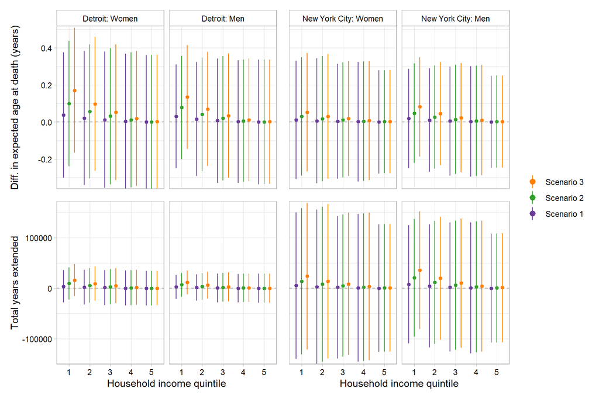

```r
#difference in mean expected age at death across scenarios at each quintile
binded %>%
  mutate(quintile=cut_interval(pctile, 5),
         gnd=factor(gnd, levels=c("Women", "Men"))) %>%
  group_by(gnd, quintile, type, czname) %>%
  summarise(meaned=mean(sim_1),
            sdd=mean(sd),
            ACS_pop=mean(ACS_pop)) %>%
  arrange(gnd, quintile, type) %>%
  ungroup() %>%
  group_by(gnd, quintile, czname) %>%
  mutate(diff=meaned-first(meaned),  #SE for difference in Mean expected age at death is sqrt(2)*[mean(SE)/sqrt(number of SE estimates)] (reduced from formula for SE of diff: sqrt[(SE 1st)^2*(SE 2nd)^2])
         diff_lower=diff-(1.96 * (sqrt(2)*sdd/sqrt(4))),
         diff_upper=diff+(1.96 * (sqrt(2)*sdd/sqrt(4))),
         diff_pop=diff*ACS_pop*0.2,
         diff_lower_pop=diff_lower*ACS_pop*0.2,
         diff_upper_pop=diff_upper*ACS_pop*0.2) %>%
  filter(type!="Observed") %>%
  dplyr::select('gnd', 'czname', 'type', 'quintile', 'diff', 'diff_lower', "diff_upper", 'diff_pop', 'diff_lower_pop', "diff_upper_pop", "ACS_pop") %>%
  mutate(czname_gnd=factor(paste(czname, gnd, sep=": "), levels=c("Detroit: Women", "Detroit: Men", "New York City: Women", "New York City: Men"))) -> deciles

#plot
p1_det <- ggplot(subset(deciles, czname=="Detroit"), aes(x=quintile, y=diff, group=type, color=type, fill=type)) +
  facet_grid(~czname_gnd) +
  geom_hline(yintercept=0, lty=2, color="darkgrey") +
  geom_pointrange(aes(y=diff, ymin=diff_lower, ymax=diff_upper), size=0.5, fatten=2, position=position_dodge(width=0.8)) +
  scale_color_manual(values=c("#6A3D9A", "#33A02C", "#FF7F00"), labels=c('Scenario 1', 'Scenario 2', 'Scenario 3')) +
  scale_fill_manual(values=c("#6A3D9A", "#33A02C", "#FF7F00"), labels=c('Scenario 1', 'Scenario 2', 'Scenario 3')) +
  ylab("Diff. in expected age at death (years)") +
  scale_y_continuous(expand=expansion(mult=c(0.0, 0.01)),  limits=c(min(deciles$diff_lower), max(deciles$diff_upper))) +
  theme_light() +
  theme(strip.background=element_rect(color="darkgrey", fill=NA), strip.text=element_text(color="black"),
        axis.title.x=element_blank(), axis.text.x=element_blank(), axis.ticks.x=element_blank(), axis.text.y=element_text(color="black"))

p1_nyc <- ggplot(subset(deciles, czname=="New York City"), aes(x=quintile, y=diff, group=type, color=type, fill=type)) +
  facet_grid(~czname_gnd) +
  geom_hline(yintercept=0, lty=2, color="darkgrey") +
  geom_pointrange(aes(y=diff, ymin=diff_lower, ymax=diff_upper), size=0.5, fatten=2, position=position_dodge(width=0.8)) +
  scale_color_manual(values=c("#6A3D9A", "#33A02C", "#FF7F00"), labels=c('Scenario 1', 'Scenario 2', 'Scenario 3')) +
  scale_fill_manual(values=c("#6A3D9A", "#33A02C", "#FF7F00"), labels=c('Scenario 1', 'Scenario 2', 'Scenario 3')) +
  scale_y_continuous(expand=expansion(mult=c(0.0, 0.01)),  limits=c(min(deciles$diff_lower), max(deciles$diff_upper))) +
  theme_light() +
  theme(strip.background=element_rect(color="darkgrey", fill=NA), strip.text=element_text(color="black"),
        axis.title.y=element_blank(), axis.text.y=element_blank(), axis.ticks.y=element_blank(),
        axis.title.x=element_blank(), axis.text.x=element_blank(), axis.ticks.x=element_blank())

p2_det <- ggplot(subset(deciles, czname=="Detroit"), aes(x=quintile, y=diff_pop, group=type, color=type, fill=type)) +
  facet_grid(~czname_gnd) +
  geom_hline(yintercept=0, lty=2, color="darkgrey") +
  geom_pointrange(aes(y=diff_pop, ymin=diff_lower_pop, ymax=diff_upper_pop), size=0.5, fatten=2, position=position_dodge(width=0.8)) +
  scale_color_manual(values=c("#6A3D9A", "#33A02C", "#FF7F00"), labels=c('Scenario 1', 'Scenario 2', 'Scenario 3')) +
  scale_fill_manual(values=c("#6A3D9A", "#33A02C", "#FF7F00"), labels=c('Scenario 1', 'Scenario 2', 'Scenario 3')) +
  ylab("Total years extended") +
  xlab("Household income quintile") +
  scale_y_continuous(expand=expansion(mult=c(0.0, 0.01)),  limits=c(min(deciles$diff_lower_pop), max(deciles$diff_upper_pop))) +
  scale_x_discrete(labels=c("1","2","3","4","5")) +
  theme_light() +
  theme(strip.background.x=element_blank(), strip.text.x=element_blank(), axis.text.x=element_text(color="black"), axis.text.y=element_text(color="black"),
        strip.background.y=element_rect(color="darkgrey", fill=NA), strip.text.y=element_text(color="black"))

p2_nyc <- ggplot(subset(deciles, czname=="New York City"), aes(x=quintile, y=diff_pop, group=type, color=type, fill=type)) +
  facet_grid(~czname_gnd) +
  geom_hline(yintercept=0, lty=2, color="darkgrey") +
  geom_pointrange(aes(y=diff_pop, ymin=diff_lower_pop, ymax=diff_upper_pop), size=0.5, fatten=2, position=position_dodge(width=0.8)) +
  scale_color_manual(values=c("#6A3D9A", "#33A02C", "#FF7F00"), labels=c('Scenario 1', 'Scenario 2', 'Scenario 3')) +
  scale_fill_manual(values=c("#6A3D9A", "#33A02C", "#FF7F00"), labels=c('Scenario 1', 'Scenario 2', 'Scenario 3')) +
  xlab("Household income quintile") +
  scale_y_continuous(expand=expansion(mult=c(0.0, 0.01)),  limits=c(min(deciles$diff_lower_pop), max(deciles$diff_upper_pop))) +
  scale_x_discrete(labels=c("1","2","3","4","5")) +
  theme_light() +
  theme(strip.background.x=element_blank(), strip.text.x=element_blank(), axis.text.x=element_text(color="black"),
        strip.background.y=element_rect(color="darkgrey", fill=NA), strip.text.y=element_text(color="black"),
        axis.title.y=element_blank(), axis.text.y=element_blank(), axis.ticks.y=element_blank())

p1_det + p1_nyc + p2_det + p2_nyc + plot_layout(guides = "collect", nrow=2) & theme(legend.position = "right", legend.title=element_blank()) & guides(color=guide_legend(reverse=T), fill=guide_legend(reverse=T))
```

```r
ggsave('appendix_6f.png', height=6, width=9, dpi=600)
```